# NCDB Meningioma 2015

All

Jason Brant

August 24, 2018

**Note: To hide the code from this document, click the button in the upper right corner.**

```r
col.width <- c(37, 10, 1, 1, 3, 1, 2, 1, 2, 1, 1, 1, 1, 1, 1, 8, 2, 2, 2, 4, 4, 1, 4, 1, 1, 1, 3, 2, 2, 8,
               2, 5, 5, 5, 4, 5, 5, 5, 4, 2, 1, 2, 1, 3, 1, 1, 1, 1, 1, 1, 3, 3, 3, 3, 3, 3, 3, 3, 3, 3, 3,
               3, 3, 3, 3, 3, 3, 3, 3, 3, 3, 3, 3, 3, 3, 6, 8, 8, 8, 2, 1, 1, 1, 1, 8, 1, 1, 8, 1, 1, 2,
               2, 5, 2, 5, 3, 1, 3, 1, 8, 8, 2, 8, 2, 8, 2, 2, 1, 8, 1, 1, 1, 1, 1, 8, 1, 2, 2, 2, 2, 2,
               1, 1, 1, 2, 1)
col.names.abr <- c("PUF_CASE_ID", "PUF_FACILITY_ID", "FACILITY_TYPE_CD",  "FACILITY_LOCATION_CD", "AGE", "SEX", "RACE",
                   "SPANISH_HISPANIC_ORIGIN", "INSURANCE_STATUS", "MED_INC_QUAR_00", "NO_HSD_QUAR_00", "UR_CD_03",
                   "MED_INC_QUAR_12", "NO_HSD_QUAR_12", "UR_CD_13", "CROWFLY", "CDCC_TOTAL", "SEQUENCE_NUMBER",
                   "CLASS_OF_CASE", "YEAR_OF_DIAGNOSIS", "PRIMARY_SITE",  "LATERALITY", "HISTOLOGY", "BEHAVIOR",
                   "GRADE", "DIAGNOSTIC_CONFIRMATION", "TUMOR_SIZE", "REGIONAL_NODES_POSITIVE",
                   "REGIONAL_NODES_EXAMINED", "DX_STAGING_PROC_DAYS", "RX_SUMM_DXSTG_PROC", "TNM_CLIN_T",
                   "TNM_CLIN_N", "TNM_CLIN_M", "TNM_CLIN_STAGE_GROUP", "TNM_PATH_T", "TNM_PATH_N", "TNM_PATH_M",
                   "TNM_PATH_STAGE_GROUP", "TNM_EDITION_NUMBER", "ANALYTIC_STAGE_GROUP", "CS_METS_AT_DX",
                   "CS_METS_EVAL", "CS_EXTENSION", "CS_TUMOR_SIZEEXT_EVAL", "CS_METS_DX_BONE",
                   "CS_METS_DX_BRAIN", "CS_METS_DX_LIVER", "CS_METS_DX_LUNG", "LYMPH_VASCULAR_INVASION",
                   "CS_SITESPECIFIC_FACTOR_1", "CS_SITESPECIFIC_FACTOR_2", "CS_SITESPECIFIC_FACTOR_3",
                   "CS_SITESPECIFIC_FACTOR_4", "CS_SITESPECIFIC_FACTOR_5", "CS_SITESPECIFIC_FACTOR_6",
                   "CS_SITESPECIFIC_FACTOR_7", "CS_SITESPECIFIC_FACTOR_8", "CS_SITESPECIFIC_FACTOR_9",
                   "CS_SITESPECIFIC_FACTOR_10", "CS_SITESPECIFIC_FACTOR_11", "CS_SITESPECIFIC_FACTOR_12",
                   "CS_SITESPECIFIC_FACTOR_13", "CS_SITESPECIFIC_FACTOR_14", "CS_SITESPECIFIC_FACTOR_15",
                   "CS_SITESPECIFIC_FACTOR_16", "CS_SITESPECIFIC_FACTOR_17", "CS_SITESPECIFIC_FACTOR_18",
                   "CS_SITESPECIFIC_FACTOR_19", "CS_SITESPECIFIC_FACTOR_20", "CS_SITESPECIFIC_FACTOR_21",
                   "CS_SITESPECIFIC_FACTOR_22", "CS_SITESPECIFIC_FACTOR_23", "CS_SITESPECIFIC_FACTOR_24",
                   "CS_SITESPECIFIC_FACTOR_25", "CS_VERSION_LATEST", "DX_RX_STARTED_DAYS",
                   "DX_SURG_STARTED_DAYS", "DX_DEFSURG_STARTED_DAYS", "RX_SUMM_SURG_PRIM_SITE",
                   "RX_HOSP_SURG_APPR_2010", "RX_SUMM_SURGICAL_MARGINS", "RX_SUMM_SCOPE_REG_LN_SUR",
                   "RX_SUMM_SURG_OTH_REGDIS", "SURG_DISCHARGE_DAYS", "READM_HOSP_30_DAYS",
                   "REASON_FOR_NO_SURGERY", "DX_RAD_STARTED_DAYS", "RX_SUMM_RADIATION", "RAD_LOCATION_OF_RX",
                   "RAD_TREAT_VOL", "RAD_REGIONAL_RX_MODALITY", "RAD_REGIONAL_DOSE_CGY",
                   "RAD_BOOST_RX_MODALITY", "RAD_BOOST_DOSE_CGY", "RAD_NUM_TREAT_VOL",
                   "RX_SUMM_SURGRAD_SEQ", "RAD_ELAPSED_RX_DAYS", "REASON_FOR_NO_RADIATION",
                   "DX_SYSTEMIC_STARTED_DAYS", "DX_CHEMO_STARTED_DAYS", "RX_SUMM_CHEMO",
                   "DX_HORMONE_STARTED_DAYS", "RX_SUMM_HORMONE", "DX_IMMUNO_STARTED_DAYS",
                   "RX_SUMM_IMMUNOTHERAPY", "RX_SUMM_TRNSPLNT_ENDO", "RX_SUMM_SYSTEMIC_SUR_SEQ",
                   "DX_OTHER_STARTED_DAYS", "RX_SUMM_OTHER", "PALLIATIVE_CARE", "RX_SUMM_TREATMENT_STATUS",
                   "PUF_30_DAY_MORT_CD", "PUF_90_DAY_MORT_CD", "DX_LASTCONTACT_DEATH_MONTHS",
                   "PUF_VITAL_STATUS", "RX_HOSP_SURG_PRIM_SITE", "RX_HOSP_CHEMO", "RX_HOSP_IMMUNOTHERAPY",
                   "RX_HOSP_HORMONE", "RX_HOSP_OTHER", "PUF_MULT_SOURCE", "REFERENCE_DATE_FLAG",
                   "RX_SUMM_SCOPE_REG_LN_2012", "RX_HOSP_DXSTG_PROC", "PALLIATIVE_CARE_HOSP")
#Read in data for each subsite
bone.joint <- read_fwf('I:/Brant/Research/NCDB/Data/Data_2017/NCDB_PUF_DATA_Nov-07-2017/NCDBPUF_BoneJont.3.2015.0.dat',
                       fwf_widths(col.width, col_names = col.names.abr),
                       col_types = cols(.default = col_character()))
brain <- read_fwf('I:/Brant/Research/NCDB/Data/Data_2017/NCDB_PUF_DATA_Nov-07-2017/NCDBPUF_Brain.3.2015.0.dat',
                       fwf_widths(col.width, col_names = col.names.abr),
                       col_types = cols(.default = col_character()))
cns <- read_fwf('I:/Brant/Research/NCDB/Data/Data_2017/NCDB_PUF_DATA_Nov-07-2017/NCDBPUF_CNS.3.2015.0.dat',
                       fwf_widths(col.width, col_names = col.names.abr),
                       col_types = cols(.default = col_character()))
gum.ot.mth <- read_fwf('I:/Brant/Research/NCDB/Data/Data_2017/NCDB_PUF_DATA_Nov-07-2017/NCDBPUF_GumOtMth.3.2015.0.dat',
                       fwf_widths(col.width, col_names = col.names.abr),
                       col_types = cols(.default = col_character()))
hypophar <- read_fwf('I:/Brant/Research/NCDB/Data/Data_2017/NCDB_PUF_DATA_Nov-07-2017/NCDBPUF_Hypophar.3.2015.0.dat',
                       fwf_widths(col.width, col_names = col.names.abr),
                       col_types = cols(.default = col_character()))
larynx <- read_fwf('I:/Brant/Research/NCDB/Data/Data_2017/NCDB_PUF_DATA_Nov-07-2017/NCDBPUF_Larynx.3.2015.0.dat',
                       fwf_widths(col.width, col_names = col.names.abr),
                       col_types = cols(.default = col_character()))
lip <- read_fwf('I:/Brant/Research/NCDB/Data/Data_2017/NCDB_PUF_DATA_Nov-07-2017/NCDBPUF_Lip.3.2015.0.dat',
                       fwf_widths(col.width, col_names = col.names.abr),
                       col_types = cols(.default = col_character()))
melanoma <- read_fwf('I:/Brant/Research/NCDB/Data/Data_2017/NCDB_PUF_DATA_Nov-07-2017/NCDBPUF_Melanoma.3.2015.0.dat',
                       fwf_widths(col.width, col_names = col.names.abr),
                       col_types = cols(.default = col_character()))
fom <- read_fwf('I:/Brant/Research/NCDB/Data/Data_2017/NCDB_PUF_DATA_Nov-07-2017/NCDBPUF_MouthFlr.3.2015.0.dat',
                       fwf_widths(col.width, col_names = col.names.abr),
                       col_types = cols(.default = col_character()))
nasal <- read_fwf('I:/Brant/Research/NCDB/Data/Data_2017/NCDB_PUF_DATA_Nov-07-2017/NCDBPUF_Nasal.3.2015.0.dat',
                       fwf_widths(col.width, col_names = col.names.abr),
                       col_types = cols(.default = col_character()))
nasophar <- read_fwf('I:/Brant/Research/NCDB/Data/Data_2017/NCDB_PUF_DATA_Nov-07-2017/NCDBPUF_Nasophar.3.2015.0.dat',
                       fwf_widths(col.width, col_names = col.names.abr),
                       col_types = cols(.default = col_character()))
orophar <- read_fwf('I:/Brant/Research/NCDB/Data/Data_2017/NCDB_PUF_DATA_Nov-07-2017/NCDBPUF_Orophary.3.2015.0.dat',
                       fwf_widths(col.width, col_names = col.names.abr),
                       col_types = cols(.default = col_character()))
oth.endo <- read_fwf('I:/Brant/Research/NCDB/Data/Data_2017/NCDB_PUF_DATA_Nov-07-2017/NCDBPUF_OtEndocr.3.2015.0.dat',
                       fwf_widths(col.width, col_names = col.names.abr),
                       col_types = cols(.default = col_character()))
skin <- read_fwf('I:/Brant/Research/NCDB/Data/Data_2017/NCDB_PUF_DATA_Nov-07-2017/NCDBPUF_OtSkin.3.2015.0.dat',
                       fwf_widths(col.width, col_names = col.names.abr),
                       col_types = cols(.default = col_character()))
pharynx <- read_fwf('I:/Brant/Research/NCDB/Data/Data_2017/NCDB_PUF_DATA_Nov-07-2017/NCDBPUF_Pharynx.3.2015.0.dat',
                       fwf_widths(col.width, col_names = col.names.abr),
                       col_types = cols(.default = col_character()))
saliv.gland <- read_fwf('I:/Brant/Research/NCDB/Data/Data_2017/NCDB_PUF_DATA_Nov-07-2017/NCDBPUF_SalivGld.3.2015.0.dat',
                       fwf_widths(col.width, col_names = col.names.abr),
                       col_types = cols(.default = col_character()))
thyroid <- read_fwf('I:/Brant/Research/NCDB/Data/Data_2017/NCDB_PUF_DATA_Nov-07-2017/NCDBPUF_Thyroid.3.2015.0.dat',
                       fwf_widths(col.width, col_names = col.names.abr),
                       col_types = cols(.default = col_character()))
tongue <- read_fwf('I:/Brant/Research/NCDB/Data/Data_2017/NCDB_PUF_DATA_Nov-07-2017/NCDBPUF_Tongue.3.2015.0.dat',
                       fwf_widths(col.width, col_names = col.names.abr),
                       col_types = cols(.default = col_character()))
tonsil <- read_fwf('I:/Brant/Research/NCDB/Data/Data_2017/NCDB_PUF_DATA_Nov-07-2017/NCDBPUF_Tonsil.3.2015.0.dat',
                       fwf_widths(col.width, col_names = col.names.abr),
                       col_types = cols(.default = col_character()))
trach.med <- read_fwf('I:/Brant/Research/NCDB/Data/Data_2017/NCDB_PUF_DATA_Nov-07-2017/NCDBPUF_TrachMed.3.2015.0.dat',
                       fwf_widths(col.width, col_names = col.names.abr),
                       col_types = cols(.default = col_character()))
#Combine data for all subsites
dat <- bind_rows(bone.joint, brain, cns, gum.ot.mth, hypophar, larynx, lip, melanoma, fom, nasal, nasophar, orophar,
                 oth.endo, skin, pharynx, saliv.gland, thyroid, tongue, tonsil, trach.med)
rm(bone.joint, brain, cns, gum.ot.mth, hypophar, larynx, lip, melanoma, fom, nasal, nasophar, orophar,
                 oth.endo, skin, pharynx, saliv.gland, thyroid, tongue, tonsil, trach.med)
prim_site_text <- data_frame(PRIMARY_SITE = c("C030", "C031", "C062", "C039", "C050", "C051", "C052", "C058", "C059", "C068",
               "C069", "C060", "C061", "C129", "C130", "C131", "C132", "C138", "C139", "C320",
               "C321", "C322", "C323", "C328", "C329", "C000", "C003", "C001", "C004", "C006",
               "C002", "C005", "C008", "C009", "C440", "C442", "C443", "C444", "C445", "C446",
               "C447", "C448", "C449", "C441", "C040", "C041", "C048", "C049", "C300", "C301",
               "C310", "C311", "C312", "C313", "C318", "C319", "C110", "C111", "C112", "C113",
               "C118", "C119", "C090", "C091", "C098", "C099", "C100", "C102", "C103", "C104",
               "C108", "C109", "C101", "C140", "C142", "C148", "C079", "C080", "C081", "C088",
               "C089", "C739", "C019", "C024", "C020", "C021", "C022", "C023", "C028", "C029"),
               SITE_TEXT = c("C03.0: Gum, upper", "C03.1 Gum, lower", "C06.2 Retromolar area", "C03.9 Gum, NOS",
               "C05.0 Hard Palate", "C05.1 Soft Palate", "C05.2 Uvula", "C05.8 Overlapping lesion of palate",
               "C05.9 Palate NOS", "C06.8 Overlapping lesion of other an unspecified parts of mouth",
               "C06.9 Mouth, NOS", "C06.0 Buccal mucosa", "C06.1 Vestibule of mouth", "C12.9  Pyriform sinus",
               "C13.0  Postcricoid region", "C13.1  Hypopharyngeal aspect of aryepiglottic fold",
               "C13.2  Posterior wall of hypopharynx", "C13.8  Overlapping lesion of hypopharynx",
               "C13.9  Hypopharynx, NOS (laryngopharynx)", "C32.0  Glottis", "C32.1  Supraglottis",
               "C32.2  Subglottis", "C32.3  Laryngeal cartilage", "C32.8  Overlapping lesion of larynx",
               "C32.9  Larynx, NOS", "C00.0  External upper lip (vermilion)", "C00.3  Mucosa of upper lip",
               "C00.1  External lower lip (vermilion)", "C00.4  Mucosa of lower lip", "C00.6  Commissure of lip",
               "C00.2  External lip, NOS (vermilion)", "C00.5  Mucosa of lip, NOS", "C00.8  Overlapping lesion of lip",
               "C00.9  Lip, NOS (excludes skin of lip C44.0)", "C44.0  Skin of lip, NOS", "C44.2  External ear",
               "C44.3  Skin of other and unspecified parts of face", "C44.4  Skin of scalp and neck",
               "C44.5  Skin of trunk", "C44.6  Skin of upper limb and shoulder", "C44.7  Skin of lower limb and hip",
               "C44.8  Overlapping lesion of skin", "C44.9  Skin, NOS", "C44.1 Eyelid",
```

```r
               "C04.0  Anterior floor of mouth", "C04.1  Lateral floor of mouth", "C04.8  Overlapping lesion of floor of mouth",
               "C04.9  Floor of mouth, NOS", "C30.0  Nasal cavity (excluding nose, NOS C76.0)", "C30.1  Middle ear",
               "C31.0  Maxillary sinus", "C31.1  Ethmoid sinus", "C31.2  Frontal sinus", "C31.3  Sphenoid sinus",
               "C31.8  Overlapping lesion of accessory sinuses", "C31.9  Accessory sinus, NOS",
               "C11.0  Superior wall of nasopharynx", "C11.1  Posterior wall of nasopharynx (excluding pharyngeal tonsil)",
               "C11.2  Lateral wall of nasopharynx", "C11.3  Anterior wall of nasopharynx",
               "C11.8  Overlapping lesion of nasopharynx", "C11.9  Nasopharynx, NOS", "C09.0  Tonsillar fossa",
               "C09.1  Tonsillar pillar", "C09.8  Overlapping lesion of tonsil",
               "C09.9  Tonsil, NOS (excluding lingual tonsil C02.4)", "C10.0  Vallecula",
               "C10.2  Lateral wall of oropharynx", "C10.3  Posterior wall of oropharynx",
               "C10.4  Branchial cleft (site of neoplasm)", "C10.8  Overlapping lesion of oropharynx",
               "C10.9  Oropharynx, NOS", "C10.1  Anterior surface of epiglottis", "C14.0  Pharynx, NOS",
               "C14.2  Waldeyer ring", "C14.8  Overlapping lesion of lip, oral cavity", "C07.9  Parotid gland",
               "C08.0  Submandibular gland", "C08.1  Sublingual gland", "C08.8  Overlapping lesion of major salivary glands",
               "C08.9  Major salivary gland, NOS", "C73.9  Thyroid gland", "C01.9  Base of tongue, NOS",
               "C02.4  Lingual tonsil", "C02.0  Dorsal surface of tongue, NOS", "C02.1  Border of tongue (Tip)",
               "C02.2  Ventral surface of tongue, NOS", "C02.3  Anterior 2/3 of tongue, NOS",
               "C02.8  Overlapping lesion of tongue", "C02.9  Tongue, NOS"),
               CS_GROUP = c("gum_upper", "gum_lower", "gum_lower", "gum_nos", "hard_palate", "soft_palate",
             "soft_palate", "other_mouth", "other_mouth", "other_mouth", "other_mouth",
             "buccal", "buccal", "hypopharynx", "hypopharynx", "hypopharynx", "hypopharynx",
             "hypopharynx", "hypopharynx", "glottis", "supraglot", "subglot", "lx_oth",
             "lx_oth", "lx_oth", "up_lip", "up_lip", "low_lip", "low_lip", "low_lip",
             "lip_oth", "lip_oth", "lip_oth", "lip_oth", "skin", "skin", "skin", "skin",
             "skin", "skin", "skin", "skin", "skin", "eyelid", "fom", "fom", "fom", "fom",
             "nasal_cavity", "mid_ear", "max_sin", "eth_sin", "oth_sin", "oth_sin",
             "oth_sin", "oth_sin", "np", "np", "np", "np", "np", "np", "op",
             "op", "op", "op", "op", "op", "op", "op", "op", "op", "ant_epi",
             "oth_phary", "oth_phary", "oth_phary", "parotid", "smglnd",
             "glnd_oth", "glnd_oth", "glnd_oth", "thyroid", "bot_lt",
             "bot_lt", "tongue_oth", "tongue_oth", "tongue_oth", "tongue_oth",
             "tongue_oth", "tongue_oth"))
dat <- merge(dat, prim_site_text, by = "PRIMARY_SITE", all.x = TRUE)
rm(prim_site_text)
fact_vars <- c("PRIMARY_SITE", "FACILITY_TYPE_CD", "FACILITY_LOCATION_CD", "SEX", "RACE", "SPANISH_HISPANIC_ORIGIN",
               "INSURANCE_STATUS", "MED_INC_QUAR_00", "NO_HSD_QUAR_00", "UR_CD_03", "MED_INC_QUAR_12",
               "NO_HSD_QUAR_12", "UR_CD_13", "CDCC_TOTAL", "SEQUENCE_NUMBER", "CLASS_OF_CASE",
               "YEAR_OF_DIAGNOSIS", "LATERALITY", "HISTOLOGY", "BEHAVIOR",
               "GRADE", "DIAGNOSTIC_CONFIRMATION", "REGIONAL_NODES_POSITIVE", "REGIONAL_NODES_EXAMINED",
               "RX_SUMM_DXSTG_PROC", "TNM_CLIN_T",
               "TNM_CLIN_N", "TNM_CLIN_M", "TNM_CLIN_STAGE_GROUP", "TNM_PATH_T", "TNM_PATH_N",
               "TNM_PATH_M", "TNM_PATH_STAGE_GROUP", "TNM_EDITION_NUMBER", "ANALYTIC_STAGE_GROUP",
               "CS_METS_AT_DX", "CS_METS_EVAL", "CS_EXTENSION", "CS_TUMOR_SIZEEXT_EVAL", "CS_METS_DX_BONE",
               "CS_METS_DX_BRAIN", "CS_METS_DX_LIVER", "CS_METS_DX_LUNG", "LYMPH_VASCULAR_INVASION",
               "CS_VERSION_LATEST", "RX_SUMM_SURG_PRIM_SITE", "RX_HOSP_SURG_APPR_2010", "RX_SUMM_SURGICAL_MARGINS",
               "RX_SUMM_SCOPE_REG_LN_SUR", "RX_SUMM_SURG_OTH_REGDIS", "READM_HOSP_30_DAYS", "REASON_FOR_NO_SURGERY",
               "RX_SUMM_RADIATION",
               "RAD_LOCATION_OF_RX", "RAD_TREAT_VOL", "RAD_REGIONAL_RX_MODALITY", "RAD_BOOST_RX_MODALITY",
               "RX_SUMM_SURGRAD_SEQ", "REASON_FOR_NO_RADIATION", "RX_SUMM_CHEMO", "RX_SUMM_HORMONE",
               "RX_SUMM_IMMUNOTHERAPY", "RX_SUMM_TRNSPLNT_ENDO", "RX_SUMM_SYSTEMIC_SUR_SEQ",
               "RX_SUMM_OTHER", "PALLIATIVE_CARE", "RX_SUMM_TREATMENT_STATUS", "PUF_30_DAY_MORT_CD",
               "PUF_90_DAY_MORT_CD", "RX_HOSP_SURG_PRIM_SITE", "RX_HOSP_CHEMO", "RX_HOSP_IMMUNOTHERAPY",
               "RX_HOSP_HORMONE", "RX_HOSP_OTHER", "PUF_MULT_SOURCE", "REFERENCE_DATE_FLAG",
               "RX_SUMM_SCOPE_REG_LN_2012",   'RX_HOSP_DXSTG_PROC', 'PALLIATIVE_CARE_HOSP')
dat[fact_vars] <- lapply(dat[fact_vars], as.character)
dat[fact_vars] <- lapply(dat[fact_vars], as.factor)
num_vars <- c("AGE", "CROWFLY", "TUMOR_SIZE", "DX_STAGING_PROC_DAYS", "DX_RX_STARTED_DAYS", "DX_SURG_STARTED_DAYS",
              "DX_DEFSURG_STARTED_DAYS", "SURG_DISCHARGE_DAYS", "DX_RAD_STARTED_DAYS",  "RAD_REGIONAL_DOSE_CGY",
              "RAD_BOOST_DOSE_CGY", "RAD_ELAPSED_RX_DAYS", "DX_SYSTEMIC_STARTED_DAYS", "DX_CHEMO_STARTED_DAYS",
              "DX_HORMONE_STARTED_DAYS", "DX_OTHER_STARTED_DAYS", "DX_LASTCONTACT_DEATH_MONTHS",
              "RAD_NUM_TREAT_VOL")
dat[num_vars] <- lapply(dat[num_vars], as.numeric)
```

```r
p_table <- function(tab_data, ...) {
  tab_data_2 <- deparse(substitute(tab_data))

  table_p <- do.call(CreateTableOne,
                     list(data = as.name(tab_data_2), includeNA = TRUE, ...))
  table_p_out <- print(table_p,
                       showAllLevels = TRUE,
                       printToggle = FALSE)
  kable(table_p_out,
        align = "c")
}
```

# Data

```r
site_code <- c("All")
histo_code <- c("9530")
behavior_code <- c("All")
data <- dat %>%
        #filter(BEHAVIOR %in% behavior_code) %>%
        #filter(PRIMARY_SITE %in% site_code) %>%
        filter(HISTOLOGY %in% histo_code) %>%
        filter(is.na(PUF_VITAL_STATUS) == FALSE) %>%
        filter(is.na(DX_LASTCONTACT_DEATH_MONTHS) == FALSE)
```

1. Site codes: All
2. Histology codes: 9530
3. Behavior codes: All

Patients were excluded if they didn’t have values for either follow up or vital status.

Patients were excluded if they had surgery to a distant site using `RX_SUMM_SURG_OTH_REGDIS`. This was done to avoid confounding of different surgical procedures. We are only interested in surgery at the primary site. These distant site surgeries were being counted in the surgery/radiation sequence and thus to simplify analysis they were removed.

```r
data %>%
        CreateTableOne(data = .,
                     vars = c("RX_SUMM_SURG_OTH_REGDIS"),
                     includeNA = TRUE) %>%
        print(.,
              showAllLevels = TRUE)
```

```
                              level Overall
  n                                 166142
  RX_SUMM_SURG_OTH_REGDIS (%) 0     162222 (97.6)
                              1        120 ( 0.1)
                              2        116 ( 0.1)
                              3         10 ( 0.0)
                              4         25 ( 0.0)
                              5          7 ( 0.0)
                              9       3642 ( 2.2)
```

```r
data <- data %>%
        filter(RX_SUMM_SURG_OTH_REGDIS == "0")
```

Whether radiation was performed was based on the `REASON_FOR_NO_RADIATION` variable. The `RADIATION_YN` variable was classified as ‘Yes’, ‘No’, or ‘Unknown’.

```r
data <- data %>%
        mutate(FACILITY_TYPE_F = fct_recode(FACILITY_TYPE_CD,
                                            "Community Cancer Program" = "1",
                                            "Comprehensive Comm Ca Program" = "2",
                                            "Academic/Research Program" = "3",
                                            "Integrated Network Ca Program" = "4",
                                            "Other" = "9")) %>%
        mutate(FACILITY_LOCATION_F = fct_recode(FACILITY_LOCATION_CD,
                                            "New England" = "1",
                                            "Middle Atlantic" = "2",
                                            "South Atlantic" = "3",
                                            "East North Central" = "4",
                                            "East South Central" = "5",
                                            "West North Central" = "6",
                                            "West South Central" = "7",
                                            "Mountain" = "8",
                                            "Pacific" = "9",
                                            "out of US" = "0")) %>%
        mutate(FACILITY_GEOGRAPHY = fct_collapse(FACILITY_LOCATION_CD,
                                                 "Northeast" = c("1", "2"),
                                                 "South" = c("3", "7"),
                                                 "Midwest" = c("4", "5", "6"),
                                                 "West" = c("8", "9"))) %>%
        mutate(AGE_F = cut(AGE, c(0, 54, 64, 74, 100))) %>%
        mutate(AGE_40 = cut(AGE, c(0, 40, 100))) %>%
        mutate(SEX_F = fct_recode(SEX,
                                "Male" = "1",
                                "Female" = "2")) %>%
        mutate(RACE_F = fct_collapse(RACE,
                                "White" = c("01"),
                                "Black" = c("02"),
                                "Asian" = c("04", "05", "06", "07", "08", "10", "11", "12", "13", "14", "15",
                                            "16", "17", "20", "21", "22", "25", "26", "27", "28", "30", "31",
                                            "32", "96", "97"),
                                "Other/Unk" = c("03", "98", "99"))) %>%
        mutate(HISPANIC = fct_collapse(SPANISH_HISPANIC_ORIGIN,
                                       "Yes" = c("1", "2", "3", "4", "5", "6", "7", "8"),
                                       "No" = c("0"),
                                       "Unknown" = c("9"))) %>%
        mutate(INSURANCE_F = fct_recode(INSURANCE_STATUS,
                                         "None" = "0",
                                         "Private" = "1",
                                         "Medicaid" = "2",
                                         "Medicare" = "3",
                                         "Other Government" = "4",
                                         "Unknown" = "9")) %>%
        mutate(INSURANCE_F = fct_relevel(INSURANCE_F,
                                         "Private")) %>%
        mutate(INCOME_F = fct_recode(MED_INC_QUAR_12,
                                      "Less than $38,000" = "1",
                                      "$38,000 - $47,999" = "2",
                                      "$48,000 - $62,999" = "3",
                                      "$63,000 +" = "4")) %>%
        mutate(EDUCATION_F = fct_recode(NO_HSD_QUAR_12,
                                        "21% or more" = "1",
                                        "13 - 20.9%" = "2",
                                        "7 - 12.9%" = "3",
                                        "Less than 7%" = "4")) %>%
        mutate(U_R_F = fct_collapse(UR_CD_13,
                                    "Metro" = c("1", "2", "3"),
                                    "Urban" = c("4", "5", "6", "7"),
                                    "Rural" = c("8", "9"))) %>%
        mutate(CLASS_OF_CASE_F = fct_collapse(CLASS_OF_CASE,
                                              All_Part_Prim = c("10", "11", "12", "13",
                                                                "14", "20", "21", "22"),
                                              Other_Facility = c("00"))) %>%
        mutate(GRADE_F = fct_recode(GRADE,
                                  "Gr I: Well Diff" = "1",
                                  "Gr II: Mod Diff" = "2",
                                  "Gr III: Poor Diff" = "3",
                                  "Gr IV: Undiff/Anaplastic" = "4",
                                  "NA/Unkown" = "9")) %>%
        mutate(HISTOLOGY_F = fct_infreq(HISTOLOGY)) %>%
        mutate(HISTOLOGY_F = factor(HISTOLOGY_F)) %>%
        mutate(HISTOLOGY_F_LIM = fct_lump(HISTOLOGY_F, prop = 0.05)) %>%
        mutate(TNM_CLIN_T = fct_recode(TNM_CLIN_T,
                                       "N_A" = "88")) %>%
        mutate(TNM_CLIN_T = fct_relevel(TNM_CLIN_T,
                                        "1")) %>%
        mutate(TNM_CLIN_N = fct_recode(TNM_CLIN_N,
                                       "N_A" = "88")) %>%
        mutate(TNM_CLIN_M = fct_recode(TNM_CLIN_M,
                                       "N_A" = "88")) %>%
        mutate(TNM_PATH_T = fct_recode(TNM_PATH_T,
                                       "N_A" = "88")) %>%
        mutate(TNM_PATH_T = fct_relevel(TNM_PATH_T,
                                        "1")) %>%
        mutate(TNM_PATH_N = fct_recode(TNM_PATH_N,
                                       "N_A" = "88")) %>%
        mutate(TNM_PATH_M = fct_recode(TNM_PATH_M,
                                       "N_A" = "88")) %>%
        mutate(TNM_CLIN_STAGE_GROUP = fct_recode(TNM_CLIN_STAGE_GROUP,
                                       "N_A" = "88")) %>%
        mutate(TNM_PATH_STAGE_GROUP = fct_recode(TNM_PATH_STAGE_GROUP,
                                       "N_A" = "88")) %>%
        mutate(MARGINS = fct_recode(RX_SUMM_SURGICAL_MARGINS,
                                    "No Residual" = "0",
                                    "Residual, NOS" = "1",
                                    "Microscopic Resid" = "2",
                                    "Macroscopic Resid" = "3",
                                    "Not evaluable" = "7",
                                    "No surg" = "8",
                                    "Unknown" = "9")) %>%
        mutate(MARGINS_YN = fct_collapse(RX_SUMM_SURGICAL_MARGINS,
                                         "Yes" = c("1", "2", "3"),
                                         "No" = c("0"),
                                         "No surg/Unk/NA" = c("7", "8", "9"))) %>%
        mutate(READM_HOSP_30_DAYS_F = fct_recode(READM_HOSP_30_DAYS,
                                                 "No_Surg_or_No_Readmit" = "0",
                                                 "Unplan_Readmit_Same" = "1",
                                                 "Plan_Readmit_Same" = "2",
                                                 "PlanUnplan_Same" = "3",
                                                 "Unknown" = "4")) %>%
        mutate(RX_SUMM_RADIATION_F = fct_recode(RX_SUMM_RADIATION,
                                                "None" = "0",
                                                "Beam Radiation" = "1",
                                                "Radioactive Implants" = "2",
                                                "Radioisotopes" = "3",
                                                "Beam + Imp or Isotopes" = "4",
                                                "Radiation, NOS" = "5",
                                                "Unknown" = "9")) %>%
        mutate(PUF_30_DAY_MORT_CD_F = fct_recode(PUF_30_DAY_MORT_CD,
                                                 "Alive_30" = "0",
                                                 "Dead_30" = "1",
                                                 "Unknown" = "9")) %>%
        mutate(PUF_90_DAY_MORT_CD_F = fct_recode(PUF_90_DAY_MORT_CD,
                                                 "Alive_90" = "0",
                                                 "Dead_90" = "1",
                                                 "Unknown" = "9")) %>%
        mutate(LYMPH_VASCULAR_INVASION_F = fct_recode(LYMPH_VASCULAR_INVASION,
                                                      "Neg_LymphVasc_Inv" = "0",
                                                      "Pos_LumphVasc_Inv" = "1",
                                                      "N_A" = "8",
                                                      "Unknown" = "9")) %>%
        mutate(RX_HOSP_SURG_APPR_2010_F = fct_recode(RX_HOSP_SURG_APPR_2010,
                                                     "No_Surg" = "0",
                                                     "Robot_Assist" = "1",
                                                     "Robot_to_Open" = "2",
                                                     "Endo_Lap" = "3",
                                                     "Endo_Lap_to_Open" = "4",
                                                     "Open_Unknown" = "5",
                                                     "Unknown" = "9")) %>%
        mutate(All = "All") %>%
        mutate(All = factor(All)) %>%
        mutate(REASON_FOR_NO_SURGERY_F = fct_recode(REASON_FOR_NO_SURGERY,
                                                    "Surg performed" = "0",
                                                    "Surg not recommended" = "1",
                                                    "No surg due to pt factors" = "2",
                                                    "No surg, pt died" = "5",
                                                    "Surg rec, not done" = "6",
                                                    "Surg rec, pt refused" = "7",
                                                    "Surg rec, unk if done" = "8",
                                                    "Unknown" = "9")) %>%
        mutate(SURGERY_YN = ifelse(REASON_FOR_NO_SURGERY == "0",
                                   "Yes",
                                   ifelse(REASON_FOR_NO_SURGERY == "9",
                                          "Ukn",
                                          "No"))) %>%
        mutate(REASON_FOR_NO_RADIATION_F = fct_recode(REASON_FOR_NO_RADIATION,
                                                    "Rad performed" = "0",
                                                    "Rad not recommended" = "1",
                                                    "No Rad due to pt factors" = "2",
                                                    "No Rad, pt died" = "5",
                                                    "Rad rec, not done" = "6",
                                                    "Rad rec, pt refused" = "7",
                                                    "Rad rec, unk if done" = "8",
                                                    "Unknown" = "9")) %>%
        mutate(RADIATION_YN = ifelse(REASON_FOR_NO_RADIATION == "0",
                                   "Yes",
                                   ifelse(REASON_FOR_NO_RADIATION == "9",
                                          "Ukn",
                                          "No"))) %>%
        mutate(SURGRAD_SEQ_F = fct_recode(RX_SUMM_SURGRAD_SEQ,
                                                   "None or Surg or Rad" = "0",
                                                   "Rad before Surg" = "2",
                                                   "Surg before Rad" = "3",
                                                   "Rad before and after Surg" = "4",
                                                   "Intraop Rad" = "5",
                                                   "Intraop Rad plus other" = "6",
                                                   "Unknown" = "9")) %>%
        mutate(SURG_RAD_SEQ = ifelse(SURGERY_YN == "Yes" & RX_SUMM_SURGRAD_SEQ == "0",
```

```r
                                     "Surg Alone",
                                     ifelse(RADIATION_YN == "Yes" & RX_SUMM_SURGRAD_SEQ == "0",
                                            "Rad Alone",
                                            ifelse(SURGERY_YN == "No" & RADIATION_YN == "No" & RX_SUMM_SURGRAD_SEQ == "0",
                                                   "No Treatement",
                                                   ifelse(RX_SUMM_SURGRAD_SEQ == "2",
                                                          "Rad then Surg",
                                                          ifelse(RX_SUMM_SURGRAD_SEQ == "3",
                                                                 "Surg then Rad",
                                                                 ifelse(RX_SUMM_SURGRAD_SEQ == "4",
                                                                        "Rad before and after Surg",
                                                                        "Other"))))))) %>%
        mutate(SURG_RAD_SEQ = fct_relevel(SURG_RAD_SEQ,
                                          "Surg Alone",
                                          "Surg then Rad",
                                          "Rad Alone")) %>%
        mutate(CHEMO_YN = fct_collapse(RX_SUMM_CHEMO,
                                       "No" = c("00", "82", "85", "86", "87"),
                                       "Yes" = c("01", "02", "03"),
                                       "Ukn" = c("88", "99"))) %>%
        mutate(SURG_RAD_SEQ_C = ifelse(SURGERY_YN == "Yes" & RX_SUMM_SURGRAD_SEQ == "0" & CHEMO_YN == "No",
                                     "Surg, No rad, No Chemo",
                                     ifelse(RADIATION_YN == "Yes" & RX_SUMM_SURGRAD_SEQ == "0" & CHEMO_YN == "No",
                                            "Rad, No Surg, No Chemo",
                                            ifelse(SURGERY_YN == "No" & RADIATION_YN == "No" & RX_SUMM_SURGRAD_SEQ == "0" & CHEMO_YN == "No",
                                                   "No Surg, No Rad, No Chemo",
                                                   ifelse(RX_SUMM_SURGRAD_SEQ == "2" & CHEMO_YN == "No",
                                                          "Rad then Surg, No Chemo",
                                                          ifelse(RX_SUMM_SURGRAD_SEQ == "3" & CHEMO_YN == "No",
                                                                 "Surg then Rad, No Chemo",
                                                                 ifelse(RX_SUMM_SURGRAD_SEQ == "4" & CHEMO_YN == "No",
                                                                        "Rad before and after Surg, No Chemo",
                                ifelse(SURGERY_YN == "Yes" & RX_SUMM_SURGRAD_SEQ == "0" & CHEMO_YN == "Yes",
                                       "Surg, No rad, Yes Chemo",
                                       ifelse(RADIATION_YN == "Yes" & RX_SUMM_SURGRAD_SEQ == "0" & CHEMO_YN == "Yes",
                                              "Rad, No Surg, Yes Chemo",
                                              ifelse(SURGERY_YN == "No" & RADIATION_YN == "No" & RX_SUMM_SURGRAD_SEQ == "0" & CHEMO_YN == "Yes",
                                                     "No Surg, No Rad, Yes Chemo",
                                                     ifelse(RX_SUMM_SURGRAD_SEQ == "2" & CHEMO_YN == "Yes",
                                                            "Rad then Surg, Yes Chemo",
                                                            ifelse(RX_SUMM_SURGRAD_SEQ == "3" & CHEMO_YN == "Yes",
                                                                   "Surg then Rad, Yes Chemo",
                                                                   ifelse(RX_SUMM_SURGRAD_SEQ == "4" & CHEMO_YN == "Yes",
                                                                          "Rad before and after Surg, Yes Chemo",
                                                                          "Other"))))))))))))) %>%
        mutate(SURG_RAD_SEQ_C = fct_infreq(SURG_RAD_SEQ_C)) %>%
        mutate(T_SIZE = as.numeric(TUMOR_SIZE)) %>%
        mutate(T_SIZE = ifelse(T_SIZE == 0,
                                "No Tumor",
                                ifelse(T_SIZE > 0 & T_SIZE < 10 | T_SIZE == 991,
                                       "< 1 cm",
                                       ifelse(T_SIZE >= 10 & T_SIZE < 20 | T_SIZE == 992,
                                              "1-2 cm",
                                              ifelse(T_SIZE >= 20 & T_SIZE < 30 | T_SIZE == 993,
                                                     "2-3 cm",
                                                     ifelse(T_SIZE >= 30 & T_SIZE < 40 | T_SIZE == 994,
                                                            "3-4 cm",
                                                            ifelse(T_SIZE >= 40 & T_SIZE < 50 | T_SIZE == 995,
                                                                   "4-5 cm",
                                                                   ifelse(T_SIZE >= 50 & T_SIZE < 60 | T_SIZE == 996,
                                                                          "5-6 cm",
                                                                          ifelse(T_SIZE >= 60 & T_SIZE <= 987 |
                                                                                         T_SIZE == 980 | T_SIZE == 989 |
                                                                                         T_SIZE == 997,
                                                                          ">6 cm",
                                                                          ifelse(T_SIZE == 988 | T_SIZE == 999,
                                                                                 "NA_unk",
                                                                                 "Microscopic focus")))))))))) %>%
        mutate(T_SIZE = factor(T_SIZE)) %>%
        mutate(T_SIZE = fct_relevel(T_SIZE,
                                     "No Tumor", "Microscopic focus", "< 1 cm", "1-2 cm", "2-3 cm", "3-4 cm",
                                       "4-5 cm", "5-6 cm", ">6 cm", "NA_unk")) %>%
        mutate(mets_at_dx = case_when(CS_METS_DX_LUNG == "1" ~ "Lung",
                                      CS_METS_DX_BONE == "1" ~ "Bone",
                                      CS_METS_DX_BRAIN == "1" ~ "Brain",
                                      CS_METS_DX_LIVER == "1" ~ "Liver",
                                      TRUE ~ "None/Other/Unk/NA"))
```

```
Unknown levels in `f`: 9Unknown levels in `f`: 0Unknown levels in `f`: 1Unknown levels in `f`: 1Unknown levels in `f`: 4Unknown levels in `f`: 5
```

```r
##I took out SITE_CODE here because it wasn't working for some reason
fact_vars_2 <- c("FACILITY_TYPE_F", "FACILITY_LOCATION_F", "AGE_F", "SEX_F", "RACE_F",
                 "HISPANIC", "INSURANCE_F", "INCOME_F", "EDUCATION_F", "U_R_F",
                 "CDCC_TOTAL", "CLASS_OF_CASE_F", "YEAR_OF_DIAGNOSIS", "PRIMARY_SITE", "HISTOLOGY",
                 "BEHAVIOR", "GRADE_F", "TNM_CLIN_T", "TNM_CLIN_N", "TNM_CLIN_M",
                 "TNM_CLIN_STAGE_GROUP", "TNM_PATH_T", "TNM_PATH_N", "TNM_PATH_M", "TNM_PATH_STAGE_GROUP",
                 "MARGINS", "READM_HOSP_30_DAYS_F", "RX_SUMM_RADIATION_F", "PUF_30_DAY_MORT_CD_F",
                 "PUF_90_DAY_MORT_CD_F", "LYMPH_VASCULAR_INVASION_F", "RX_HOSP_SURG_APPR_2010_F", "mets_at_dx")
data <- data %>%
        mutate_at(fact_vars_2, funs(factor(.)))
```

## Table of variables for all cases:

```r
data <- data %>%
        mutate(PRIMARY_SITE = fct_infreq(PRIMARY_SITE))
p_table(data,
        vars = c("FACILITY_TYPE_F", "FACILITY_LOCATION_F", "FACILITY_GEOGRAPHY",  "AGE", "AGE_F", "AGE_40",
                 "SEX_F", "RACE_F", "HISPANIC", "INSURANCE_F",
                 "INCOME_F", "EDUCATION_F", "U_R_F", "CROWFLY", "CDCC_TOTAL",
                 "PRIMARY_SITE", "HISTOLOGY_F_LIM", "HISTOLOGY_F", "BEHAVIOR", "GRADE_F",
                 "DX_STAGING_PROC_DAYS", "TNM_CLIN_T", "TNM_CLIN_N", "TNM_CLIN_M",
                 "TNM_CLIN_STAGE_GROUP", "TNM_PATH_T", "TNM_PATH_N", "TNM_PATH_M",
                 "TNM_PATH_STAGE_GROUP", "DX_RX_STARTED_DAYS", "DX_SURG_STARTED_DAYS",
                 "DX_DEFSURG_STARTED_DAYS", "MARGINS", "MARGINS_YN", "SURG_DISCHARGE_DAYS",
                 "READM_HOSP_30_DAYS_F", "RX_SUMM_RADIATION_F", "PUF_30_DAY_MORT_CD_F",
                 "PUF_90_DAY_MORT_CD_F", "DX_LASTCONTACT_DEATH_MONTHS",
                 "LYMPH_VASCULAR_INVASION_F", "RX_HOSP_SURG_APPR_2010_F", "SURG_RAD_SEQ",
                 "SURG_RAD_SEQ_C", "T_SIZE", "SURGERY_YN", "RADIATION_YN", "CHEMO_YN", "mets_at_dx"))
```

```
|                                        |                level                |    Overall     |
|:---------------------------------------|:-----------------------------------:|:--------------:|
|n                                       |                                     |     162222     |
|FACILITY_TYPE_F (%)                     |      Community Cancer Program       | 10635 (  6.6)  |
|                                        |    Comprehensive Comm Ca Program    | 60299 ( 37.2)  |
|                                        |      Academic/Research Program      | 61165 ( 37.7)  |
|                                        |    Integrated Network Ca Program    | 20127 ( 12.4)  |
|                                        |                 NA                  |  9996 (  6.2)  |
|FACILITY_LOCATION_F (%)                 |             New England             |  6919 (  4.3)  |
|                                        |           Middle Atlantic           | 25096 ( 15.5)  |
|                                        |           South Atlantic            | 33946 ( 20.9)  |
|                                        |         East North Central          | 24847 ( 15.3)  |
|                                        |         East South Central          | 10918 (  6.7)  |
|                                        |         West North Central          | 10948 (  6.7)  |
|                                        |         West South Central          | 14114 (  8.7)  |
|                                        |              Mountain               |  7742 (  4.8)  |
|                                        |               Pacific               | 17696 ( 10.9)  |
|                                        |                 NA                  |  9996 (  6.2)  |
|FACILITY_GEOGRAPHY (%)                  |              Northeast              | 32015 ( 19.7)  |
|                                        |                South                | 48060 ( 29.6)  |
|                                        |               Midwest               | 46713 ( 28.8)  |
|                                        |                West                 | 25438 ( 15.7)  |
|                                        |                 NA                  |  9996 (  6.2)  |
|AGE (mean (sd))                         |                                     | 64.86 (15.65)  |
|AGE_F (%)                               |               (0,54]                | 42567 ( 26.2)  |
|                                        |               (54,64]               | 33259 ( 20.5)  |
|                                        |               (64,74]               | 35653 ( 22.0)  |
|                                        |              (74,100]               | 50709 ( 31.3)  |
|                                        |                 NA                  |   34 (  0.0)   |
|AGE_40 (%)                              |               (0,40]                | 11169 (  6.9)  |
|                                        |              (40,100]               | 151019 ( 93.1) |
|                                        |                 NA                  |   34 (  0.0)   |
|SEX_F (%)                               |                Male                 | 41745 ( 25.7)  |
|                                        |               Female                | 120477 ( 74.3) |
|RACE_F (%)                              |                White                | 132725 ( 81.8) |
|                                        |                Black                | 20028 ( 12.3)  |
|                                        |              Other/Unk              |  4486 (  2.8)  |
|                                        |                Asian                |  4983 (  3.1)  |
|HISPANIC (%)                            |                 No                  | 143329 ( 88.4) |
|                                        |                 Yes                 |  9714 (  6.0)  |
```

[output cut: 165 more lines]

```
|                                        |               NA_unk                | 29257 ( 18.0)  |
|SURGERY_YN (%)                          |                 No                  | 105054 ( 64.8) |
|                                        |                 Ukn                 |  3052 (  1.9)  |
|                                        |                 Yes                 | 54116 ( 33.4)  |
|RADIATION_YN (%)                        |                 No                  | 144804 ( 89.3) |
|                                        |                 Ukn                 |  1817 (  1.1)  |
|                                        |                 Yes                 | 15601 (  9.6)  |
|CHEMO_YN (%)                            |                 No                  | 157679 ( 97.2) |
|                                        |                 Yes                 |  230 (  0.1)   |
|                                        |                 Ukn                 |  4313 (  2.7)  |
|mets_at_dx (%)                          |                Bone                 |   51 (  0.0)   |
|                                        |                Brain                |   6 (  0.0)    |
|                                        |                Liver                |   2 (  0.0)    |
|                                        |                Lung                 |   7 (  0.0)    |
|                                        |          None/Other/Unk/NA          | 162156 (100.0) |
```

## Treatment by Year

```r
p_table(data,
        vars = c("SURG_RAD_SEQ"),
        strata = c("YEAR_OF_DIAGNOSIS"))
```

```
|                 |           level           |    2004     |    2005     |    2006     |    2007     |    2008     |    2009     |    2010     |     2011     |     2012     |     2013     |     2014     |   p    | test |
|:----------------|:-------------------------:|:-----------:|:-----------:|:-----------:|:-----------:|:-----------:|:-----------:|:-----------:|:------------:|:------------:|:------------:|:------------:|:------:|:----:|
|n                |                           |    9636     |    11098    |    12274    |    13289    |    14558    |    15828    |    15845    |    16626     |    17003     |    17727     |    18338     |        |      |
|SURG_RAD_SEQ (%) |        Surg Alone         | 3860 (40.1) | 4032 (36.3) | 4188 (34.1) | 4404 (33.1) | 4591 (31.5) | 4552 (28.8) | 4469 (28.2) | 4736 (28.5)  | 4692 (27.6)  | 4945 (27.9)  | 5093 (27.8)  | <0.001 |      |
|                 |       Surg then Rad       | 250 ( 2.6)  | 257 ( 2.3)  | 301 ( 2.5)  | 266 ( 2.0)  | 325 ( 2.2)  | 343 ( 2.2)  | 362 ( 2.3)  |  359 ( 2.2)  |  368 ( 2.2)  |  458 ( 2.6)  |  439 ( 2.4)  |        |      |
|                 |         Rad Alone         | 898 ( 9.3)  | 986 ( 8.9)  | 1114 ( 9.1) | 1076 ( 8.1) | 1104 ( 7.6) | 1220 ( 7.7) | 1139 ( 7.2) | 1033 ( 6.2)  | 1065 ( 6.3)  | 1071 ( 6.0)  | 1030 ( 5.6)  |        |      |
|                 |       No Treatement       | 4294 (44.6) | 5358 (48.3) | 6200 (50.5) | 7060 (53.1) | 8031 (55.2) | 9209 (58.2) | 9497 (59.9) | 10184 (61.3) | 10592 (62.3) | 11015 (62.1) | 11509 (62.8) |        |      |
|                 |           Other           | 325 ( 3.4)  | 453 ( 4.1)  | 466 ( 3.8)  | 474 ( 3.6)  | 497 ( 3.4)  | 497 ( 3.1)  | 373 ( 2.4)  |  305 ( 1.8)  |  282 ( 1.7)  |  235 ( 1.3)  |  263 ( 1.4)  |        |      |
|                 | Rad before and after Surg |  0 ( 0.0)   |  1 ( 0.0)   |  0 ( 0.0)   |  1 ( 0.0)   |  0 ( 0.0)   |  0 ( 0.0)   |  0 ( 0.0)   |   0 ( 0.0)   |   0 ( 0.0)   |   0 ( 0.0)   |   0 ( 0.0)   |        |      |
|                 |       Rad then Surg       |  9 ( 0.1)   |  11 ( 0.1)  |  5 ( 0.0)   |  8 ( 0.1)   |  10 ( 0.1)  |  7 ( 0.0)   |  5 ( 0.0)   |   9 ( 0.1)   |   4 ( 0.0)   |   3 ( 0.0)   |   4 ( 0.0)   |        |      |
```

```
Ignoring unknown parameters: binwidth, bins, pad
```

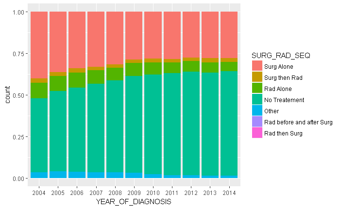

```r
data %>%
    ggplot(aes(x = YEAR_OF_DIAGNOSIS)) +
    geom_histogram(stat = "count", aes (fill = SURG_RAD_SEQ), position = "fill")
```

## Treatment by region

```r
p_table(data,
        vars = c("SURG_RAD_SEQ"),
        strata = c("FACILITY_LOCATION_F"))
```

```
|                 |           level           | New England | Middle Atlantic | South Atlantic | East North Central | East South Central | West North Central | West South Central |  Mountain   |   Pacific    |   p    | test |
|:----------------|:-------------------------:|:-----------:|:---------------:|:--------------:|:------------------:|:------------------:|:------------------:|:------------------:|:-----------:|:------------:|:------:|:----:|
|n                |                           |    6919     |      25096      |     33946      |       24847        |       10918        |       10948        |       14114        |    7742     |    17696     |        |      |
|SURG_RAD_SEQ (%) |        Surg Alone         | 1931 (27.9) |   7223 (28.8)   |  10658 (31.4)  |    6325 (25.5)     |    3019 (27.7)     |    3486 (31.8)     |    4395 (31.1)     | 1812 (23.4) | 5691 (32.2)  | <0.001 |      |
|                 |       Surg then Rad       | 153 ( 2.2)  |   555 ( 2.2)    |   744 ( 2.2)   |     498 ( 2.0)     |     158 ( 1.4)     |     220 ( 2.0)     |     249 ( 1.8)     | 122 ( 1.6)  |  553 ( 3.1)  |        |      |
|                 |         Rad Alone         | 523 ( 7.6)  |   2120 ( 8.4)   |  2554 ( 7.5)   |    1512 ( 6.1)     |     693 ( 6.3)     |     929 ( 8.5)     |     775 ( 5.5)     | 620 ( 8.0)  | 1256 ( 7.1)  |        |      |
|                 |       No Treatement       | 4094 (59.2) |  14372 (57.3)   |  19364 (57.0)  |    15938 (64.1)    |    6957 (63.7)     |    6153 (56.2)     |    7972 (56.5)     | 4577 (59.1) | 10046 (56.8) |        |      |
|                 |           Other           | 215 ( 3.1)  |   816 ( 3.3)    |   606 ( 1.8)   |     560 ( 2.3)     |     86 ( 0.8)      |     158 ( 1.4)     |     717 ( 5.1)     | 607 ( 7.8)  |  142 ( 0.8)  |        |      |
|                 | Rad before and after Surg |  0 ( 0.0)   |    0 ( 0.0)     |    0 ( 0.0)    |      1 ( 0.0)      |      0 ( 0.0)      |      0 ( 0.0)      |      0 ( 0.0)      |  0 ( 0.0)   |   1 ( 0.0)   |        |      |
|                 |       Rad then Surg       |  3 ( 0.0)   |    10 ( 0.0)    |   20 ( 0.1)    |     13 ( 0.1)      |      5 ( 0.0)      |      2 ( 0.0)      |      6 ( 0.0)      |  4 ( 0.1)   |   7 ( 0.0)   |        |      |
```

## Treatment by tumor size

```r
p_table(data,
        vars = c("SURG_RAD_SEQ"),
        strata = c("T_SIZE"))
```

```
|                 |           level           | No Tumor  | Microscopic focus |    < 1 cm    |    1-2 cm    |    2-3 cm    |   3-4 cm    |   4-5 cm    |   5-6 cm    |    >6 cm    |    NA_unk    |   p    | test |
|:----------------|:-------------------------:|:---------:|:-----------------:|:------------:|:------------:|:------------:|:-----------:|:-----------:|:-----------:|:-----------:|:------------:|:------:|:----:|
|n                |                           |    60     |        58         |    14837     |    44691     |    29560     |    17799    |    11271    |    6922     |    7767     |    29257     |        |      |
|SURG_RAD_SEQ (%) |        Surg Alone         | 20 (33.3) |     22 (37.9)     |  764 ( 5.1)  | 4815 (10.8)  | 7750 (26.2)  | 7748 (43.5) | 6549 (58.1) | 4575 (66.1) | 4770 (61.4) | 12549 (42.9) | <0.001 |      |
|                 |       Surg then Rad       | 1 ( 1.7)  |     2 ( 3.4)      |  45 ( 0.3)   |  187 ( 0.4)  |  386 ( 1.3)  | 601 ( 3.4)  | 584 ( 5.2)  | 410 ( 5.9)  | 489 ( 6.3)  | 1023 ( 3.5)  |        |      |
|                 |         Rad Alone         | 5 ( 8.3)  |     0 ( 0.0)      |  535 ( 3.6)  | 3142 ( 7.0)  | 3142 (10.6)  | 1472 ( 8.3) | 472 ( 4.2)  | 205 ( 3.0)  | 299 ( 3.8)  | 2464 ( 8.4)  |        |      |
|                 |       No Treatement       | 32 (53.3) |     34 (58.6)     | 13080 (88.2) | 35319 (79.0) | 17500 (59.2) | 7539 (42.4) | 3411 (30.3) | 1580 (22.8) | 2022 (26.0) | 12432 (42.5) |        |      |
|                 |           Other           | 2 ( 3.3)  |     0 ( 0.0)      |  412 ( 2.8)  | 1222 ( 2.7)  |  763 ( 2.6)  | 428 ( 2.4)  | 248 ( 2.2)  | 146 ( 2.1)  | 180 ( 2.3)  |  769 ( 2.6)  |        |      |
|                 | Rad before and after Surg | 0 ( 0.0)  |     0 ( 0.0)      |   0 ( 0.0)   |   0 ( 0.0)   |   1 ( 0.0)   |  0 ( 0.0)   |  0 ( 0.0)   |  0 ( 0.0)   |  0 ( 0.0)   |   1 ( 0.0)   |        |      |
|                 |       Rad then Surg       | 0 ( 0.0)  |     0 ( 0.0)      |   1 ( 0.0)   |   6 ( 0.0)   |  18 ( 0.1)   |  11 ( 0.1)  |  7 ( 0.1)   |  6 ( 0.1)   |  7 ( 0.1)   |  19 ( 0.1)   |        |      |
```

```
Ignoring unknown parameters: binwidth, bins, pad
```

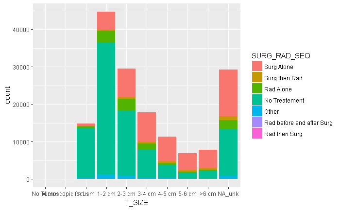

```r
data %>%
    ggplot(aes(x = T_SIZE)) +
    geom_histogram(stat = "count", aes (fill = SURG_RAD_SEQ))
```

# Tumor size by year

```r
p_table(data,
        vars = c("TUMOR_SIZE"),
        strata = c("YEAR_OF_DIAGNOSIS"))
```

```
|                       | level |      2004       |      2005       |      2006       |      2007       |      2008       |      2009       |      2010       |      2011       |      2012       |      2013       |      2014       |   p    | test |
|:----------------------|:-----:|:---------------:|:---------------:|:---------------:|:---------------:|:---------------:|:---------------:|:---------------:|:---------------:|:---------------:|:---------------:|:---------------:|:------:|:----:|
|n                      |       |      9636       |      11098      |      12274      |      13289      |      14558      |      15828      |      15845      |      16626      |      17003      |      17727      |      18338      |        |      |
|TUMOR_SIZE (mean (sd)) |       | 329.90 (448.51) | 300.59 (436.51) | 277.65 (424.88) | 259.44 (414.40) | 218.04 (386.86) | 211.22 (381.06) | 184.55 (359.80) | 174.51 (350.62) | 165.82 (342.58) | 156.10 (332.07) | 145.15 (319.85) | <0.001 |      |
```

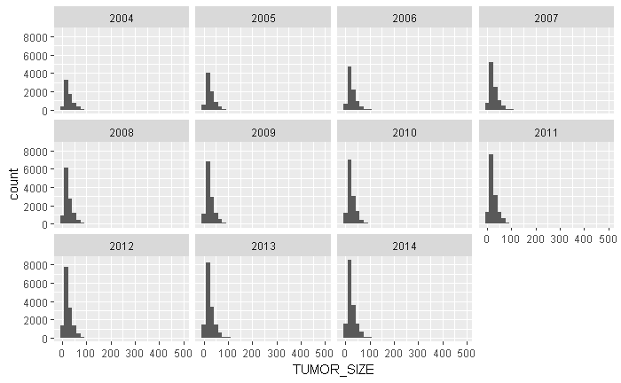

```r
data %>%
    filter(TUMOR_SIZE < 500) %>%
    ggplot(aes(x = TUMOR_SIZE)) +
    geom_histogram() +
    facet_wrap(~ YEAR_OF_DIAGNOSIS)
```

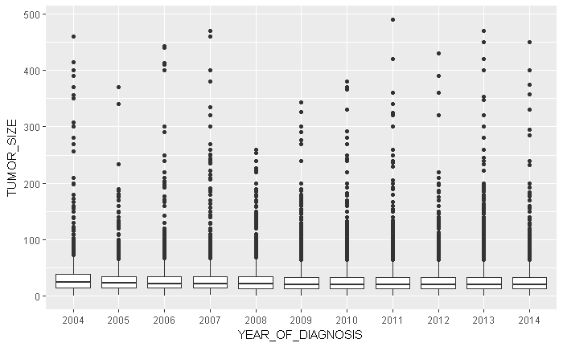

```r
data %>%
    filter(TUMOR_SIZE < 500) %>%
    ggplot(aes(x = YEAR_OF_DIAGNOSIS, y = TUMOR_SIZE)) +
    geom_boxplot()
```

# Treatment models

### Model for surgery

```r
data <- data %>%
        mutate(FACILITY_LOCATION_F = fct_relevel(FACILITY_LOCATION_F,
                                             "New England")) %>%
        mutate(SURG_TX = case_when(SURGERY_YN == "Yes" ~ TRUE,
                                   SURGERY_YN == "No" ~ FALSE,
                                   TRUE ~ NA)) %>%
        mutate(YEAR_OF_DIAGNOSIS = fct_relevel(YEAR_OF_DIAGNOSIS,
                                               "2014"))
fit_surg <- glm(SURG_TX ~ AGE + SEX + CDCC_TOTAL + T_SIZE + FACILITY_TYPE_F + FACILITY_LOCATION_F +
                        YEAR_OF_DIAGNOSIS,
                family = "binomial",
                data = data)
summary(fit_surg)
```

```
Call:
glm(formula = SURG_TX ~ AGE + SEX + CDCC_TOTAL + T_SIZE + FACILITY_TYPE_F +
    FACILITY_LOCATION_F + YEAR_OF_DIAGNOSIS, family = "binomial",
    data = data)

Deviance Residuals:
    Min       1Q   Median       3Q      Max
-2.4693  -0.7051  -0.3507   0.7532   3.2014

Coefficients:
                                               Estimate Std. Error  z value Pr(>|z|)
(Intercept)                                   2.2709392  0.3055474    7.432 1.07e-13 ***
AGE                                          -0.0611322  0.0005524 -110.659  < 2e-16 ***
SEX2                                         -0.0610966  0.0152066   -4.018 5.88e-05 ***
CDCC_TOTAL1                                   0.2690156  0.0177545   15.152  < 2e-16 ***
CDCC_TOTAL2                                   0.1488131  0.0288582    5.157 2.51e-07 ***
CDCC_TOTAL3                                  -0.1137277  0.0404175   -2.814   0.0049 **
T_SIZEMicroscopic focus                      -0.2043507  0.4381476   -0.466   0.6409
T_SIZE< 1 cm                                 -2.4919771  0.3022778   -8.244  < 2e-16 ***
T_SIZE1-2 cm                                 -1.6560086  0.3001978   -5.516 3.46e-08 ***
T_SIZE2-3 cm                                 -0.4596462  0.3001005   -1.532   0.1256
T_SIZE3-4 cm                                  0.4900354  0.3002390    1.632   0.1026
T_SIZE4-5 cm                                  1.2060773  0.3005776    4.013 6.01e-05 ***
T_SIZE5-6 cm                                  1.6424620  0.3013122    5.451 5.01e-08 ***
T_SIZE>6 cm                                   1.3417958  0.3010589    4.457 8.31e-06 ***
T_SIZENA_unk                                  0.3261812  0.3000815    1.087   0.2770
FACILITY_TYPE_FComprehensive Comm Ca Program  0.7561736  0.0341684   22.131  < 2e-16 ***
FACILITY_TYPE_FAcademic/Research Program      1.2924255  0.0339231   38.099  < 2e-16 ***
FACILITY_TYPE_FIntegrated Network Ca Program  0.9235468  0.0373941   24.698  < 2e-16 ***
FACILITY_LOCATION_FMiddle Atlantic           -0.0134956  0.0356216   -0.379   0.7048
FACILITY_LOCATION_FSouth Atlantic             0.2042100  0.0350355    5.829 5.59e-09 ***
FACILITY_LOCATION_FEast North Central        -0.0282197  0.0361979   -0.780   0.4356
FACILITY_LOCATION_FEast South Central         0.0157093  0.0408112    0.385   0.7003
FACILITY_LOCATION_FWest North Central         0.2341944  0.0402247    5.822 5.81e-09 ***
FACILITY_LOCATION_FWest South Central         0.2410927  0.0387149    6.227 4.74e-10 ***
FACILITY_LOCATION_FMountain                   0.0744207  0.0450275    1.653   0.0984 .
FACILITY_LOCATION_FPacific                    0.3889236  0.0374587   10.383  < 2e-16 ***
YEAR_OF_DIAGNOSIS2004                         0.3755982  0.0332104   11.310  < 2e-16 ***
YEAR_OF_DIAGNOSIS2005                         0.2770711  0.0320312    8.650  < 2e-16 ***
YEAR_OF_DIAGNOSIS2006                         0.2190784  0.0313977    6.978 3.00e-12 ***
YEAR_OF_DIAGNOSIS2007                         0.1388770  0.0308542    4.501 6.76e-06 ***
YEAR_OF_DIAGNOSIS2008                         0.1554619  0.0302451    5.140 2.75e-07 ***
YEAR_OF_DIAGNOSIS2009                        -0.0239671  0.0298648   -0.803   0.4223
YEAR_OF_DIAGNOSIS2010                        -0.0327074  0.0299476   -1.092   0.2748
YEAR_OF_DIAGNOSIS2011                         0.0005013  0.0295671    0.017   0.9865
YEAR_OF_DIAGNOSIS2012                        -0.0270561  0.0294450   -0.919   0.3582
YEAR_OF_DIAGNOSIS2013                         0.0119896  0.0291145    0.412   0.6805
---
Signif. codes:  0 *** 0.001 ** 0.01 * 0.05 . 0.1   1

(Dispersion parameter for binomial family taken to be 1)

    Null deviance: 188331  on 149341  degrees of freedom
Residual deviance: 136055  on 149306  degrees of freedom
  (12880 observations deleted due to missingness)
AIC: 136127

Number of Fisher Scoring iterations: 5
```

```r
exp(cbind("Odds ratio" = coef(fit_surg), confint.default(fit_surg, level = 0.95)))
```

```
                                             Odds ratio      2.5 %     97.5 %
(Intercept)                                  9.68849629 5.32321437 17.6335112
AGE                                          0.94069888 0.93968088  0.9417180
SEX2                                         0.94073232 0.91310801  0.9691924
CDCC_TOTAL1                                  1.30867555 1.26391924  1.3550167
CDCC_TOTAL2                                  1.16045609 1.09664121  1.2279844
CDCC_TOTAL3                                  0.89250098 0.82452772  0.9660779
T_SIZEMicroscopic focus                      0.81517641 0.34538199  1.9239931
T_SIZE< 1 cm                                 0.08274621 0.04575607  0.1496399
T_SIZE1-2 cm                                 0.19089943 0.10599266  0.3438218
T_SIZE2-3 cm                                 0.63150704 0.35069712  1.1371669
T_SIZE3-4 cm                                 1.63237401 0.90626611  2.9402456
T_SIZE4-5 cm                                 3.34035581 1.85327811  6.0206706
T_SIZE5-6 cm                                 5.16787732 2.86308865  9.3280227
T_SIZE>6 cm                                  3.82590795 2.12066817  6.9023395
T_SIZENA_unk                                 1.38566645 0.76953589  2.4951033
FACILITY_TYPE_FComprehensive Comm Ca Program 2.13010985 1.99213044  2.2776460
FACILITY_TYPE_FAcademic/Research Program     3.64160844 3.40735834  3.8919628
FACILITY_TYPE_FIntegrated Network Ca Program 2.51820627 2.34024527  2.7097001
FACILITY_LOCATION_FMiddle Atlantic           0.98659508 0.92006346  1.0579377
FACILITY_LOCATION_FSouth Atlantic            1.22655566 1.14515680  1.3137404
FACILITY_LOCATION_FEast North Central        0.97217475 0.90559217  1.0436527
FACILITY_LOCATION_FEast South Central        1.01583336 0.93774317  1.1004265
FACILITY_LOCATION_FWest North Central        1.26389014 1.16807312  1.3675670
FACILITY_LOCATION_FWest South Central        1.27263897 1.17964408  1.3729649
FACILITY_LOCATION_FMountain                  1.07725987 0.98626363  1.1766517
FACILITY_LOCATION_FPacific                   1.47539175 1.37095276  1.5877869
YEAR_OF_DIAGNOSIS2004                        1.45586199 1.36411649  1.5537780
YEAR_OF_DIAGNOSIS2005                        1.31926022 1.23898340  1.4047384
YEAR_OF_DIAGNOSIS2006                        1.24492893 1.17062774  1.3239461
YEAR_OF_DIAGNOSIS2007                        1.14898278 1.08155947  1.2206092
YEAR_OF_DIAGNOSIS2008                        1.16819738 1.10096000  1.2395411
YEAR_OF_DIAGNOSIS2009                        0.97631787 0.92081048  1.0351713
YEAR_OF_DIAGNOSIS2010                        0.96782175 0.91264924  1.0263296
YEAR_OF_DIAGNOSIS2011                        1.00050144 0.94416986  1.0601939
YEAR_OF_DIAGNOSIS2012                        0.97330663 0.91872615  1.0311297
YEAR_OF_DIAGNOSIS2013                        1.01206179 0.95592703  1.0714930
```

# Kaplan Meier Analysis

```r
uni_var <- function(test_var, data_imp) {

        cat("_________________________________________________")
        cat("\n")
        cat("   \n##", test_var)
        cat("\n")
        cat("_________________________________________________")
        cat("\n")

        f <- as.formula(paste("Surv(DX_LASTCONTACT_DEATH_MONTHS, PUF_VITAL_STATUS == 0)",
                              as.name(test_var),
                              sep = " ~ " ))

        data_imp_2 <- deparse(substitute(data_imp))
        km_fit <- do.call("survfit", list(formula = f, data = as.name(data_imp_2)))
        print(km_fit)
        cat("\n")
        print(summary(km_fit, times = c(12, 24, 36, 48, 60, 120)))
        cat("\n")
        cat("\n")
        cat("\n")
        cat("   \n## Univariable Cox Proportional Hazard Model for: ", test_var)
        cat("\n")
        cat("\n")
        n_levels <- nlevels(data_imp[[test_var]])
        if(n_levels == 1){
                print("Only one level, no Cox model performed")
                cat("\n")
        } else {
                cox_fit <- do.call("coxph", list(formula = f, data = as.name(data_imp_2)))
                print(summary(cox_fit))
                cat("\n")

                do.call("ggforest",
                         list(model = cox_fit, data = as.name(data_imp_2)))
        }
        cat("\n")
        cat("\n")
        cat("\n")
        cat("   \n## Unadjusted Kaplan Meier Overall Survival Curve for: ", test_var)
        p <- do.call("ggsurvplot",
                     list(fit = km_fit, data = as.name(data_imp_2),
                          palette = "jco", censor = FALSE, legend = "right",
                          linetype = "strata", xlab = "Time (Months)"))
        print(p)
}
```

## All

```r
data <- data %>% filter(CLASS_OF_CASE != "00") # excluding patients diagnosed at reporting/primary site and treated elsewhere
uni_var(test_var = "All", data_imp = data)
```

[output not shown]

```
_________________________________________________

## All
_________________________________________________
Call: survfit(formula = Surv(DX_LASTCONTACT_DEATH_MONTHS, PUF_VITAL_STATUS ==
    0) ~ All, data = data)

      n  events  median 0.95LCL 0.95UCL
 145879   39318     148     146     150

Call: survfit(formula = Surv(DX_LASTCONTACT_DEATH_MONTHS, PUF_VITAL_STATUS ==
    0) ~ All, data = data)

 time n.risk n.event survival  std.err lower 95% CI upper 95% CI
   12 123637   14819    0.896 0.000811        0.894        0.897
   24 106626    6011    0.850 0.000958        0.849        0.852
   36  88083    4462    0.812 0.001073        0.810        0.814
   48  71520    3604    0.776 0.001181        0.774        0.779
   60  56224    2919    0.741 0.001292        0.739        0.744
  120   8867    6934    0.581 0.002191        0.577        0.586




## Univariable Cox Proportional Hazard Model for:  All

[1] "Only one level, no Cox model performed"





## Unadjusted Kaplan Meier Overall Survival Curve for:  All
```

## Facility Type

```
_________________________________________________

## FACILITY_TYPE_F
_________________________________________________
Call: survfit(formula = Surv(DX_LASTCONTACT_DEATH_MONTHS, PUF_VITAL_STATUS ==
    0) ~ FACILITY_TYPE_F, data = data)

   9140 observations deleted due to missingness
                                                  n events median 0.95LCL 0.95UCL
FACILITY_TYPE_F=Academic/Research Program     58059  13162  154.9     151      NA
FACILITY_TYPE_F=Community Cancer Program       8439   3209   92.9      89    98.8
FACILITY_TYPE_F=Comprehensive Comm Ca Program 52599  17418  120.3     117   123.2
FACILITY_TYPE_F=Integrated Network Ca Program 17642   5134  139.2     131      NA

Call: survfit(formula = Surv(DX_LASTCONTACT_DEATH_MONTHS, PUF_VITAL_STATUS ==
    0) ~ FACILITY_TYPE_F, data = data)

9140 observations deleted due to missingness
                FACILITY_TYPE_F=Academic/Research Program
 time n.risk n.event survival std.err lower 95% CI upper 95% CI
   12  50256    4841    0.915 0.00117        0.912        0.917
   24  43742    1935    0.878 0.00139        0.875        0.881
   36  36347    1472    0.846 0.00157        0.843        0.849
   48  29701    1220    0.815 0.00174        0.812        0.819
   60  23466     991    0.785 0.00192        0.782        0.789
  120   3883    2474    0.637 0.00341        0.630        0.644

                FACILITY_TYPE_F=Community Cancer Program
 time n.risk n.event survival std.err lower 95% CI upper 95% CI
   12   6735    1244    0.848 0.00398        0.840        0.856
   24   5680     503    0.782 0.00463        0.773        0.791
   36   4598     351    0.730 0.00508        0.720        0.740
   48   3598     295    0.679 0.00553        0.669        0.690
   60   2782     244    0.629 0.00599        0.617        0.641
  120    366     533    0.431 0.00924        0.413        0.449

                FACILITY_TYPE_F=Comprehensive Comm Ca Program
 time n.risk n.event survival std.err lower 95% CI upper 95% CI
   12  43420    6715    0.869 0.00149        0.866        0.872
   24  37059    2668    0.814 0.00174        0.810        0.817
```

[output cut: 29 more lines]

```
FACILITY_TYPE_FComprehensive Comm Ca Program 0.45154   1.57073  0.01155 39.09   <2e-16 ***
FACILITY_TYPE_FIntegrated Network Ca Program 0.29415   1.34198  0.01646 17.88   <2e-16 ***
---
Signif. codes:  0 *** 0.001 ** 0.01 * 0.05 . 0.1   1

                                             exp(coef) exp(-coef) lower .95 upper .95
FACILITY_TYPE_FCommunity Cancer Program          1.912     0.5230     1.839     1.987
FACILITY_TYPE_FComprehensive Comm Ca Program     1.571     0.6366     1.536     1.607
FACILITY_TYPE_FIntegrated Network Ca Program     1.342     0.7452     1.299     1.386

Concordance= 0.561  (se = 0.001 )
Rsquare= 0.015   (max possible= 0.998 )
Likelihood ratio test= 2000  on 3 df,   p=0
Wald test            = 1971  on 3 df,   p=0
Score (logrank) test = 2009  on 3 df,   p=0
```

```
Removed 1 rows containing missing values (geom_errorbar).
```

```
## Unadjusted Kaplan Meier Overall Survival Curve for:  FACILITY_TYPE_F
```

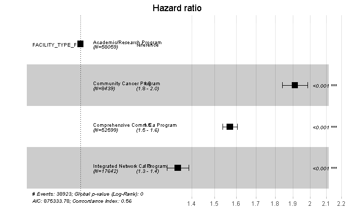

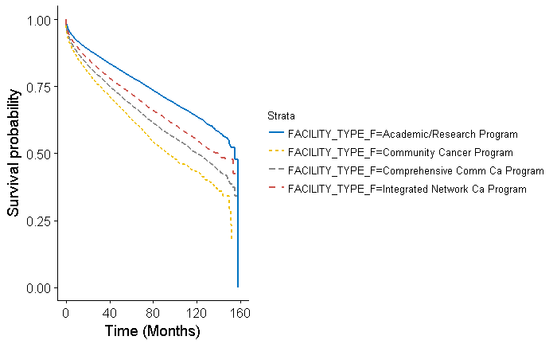

```r
data$FACILITY_TYPE_F <- fct_relevel(data$FACILITY_TYPE_F, "Academic/Research Program", after = 0)
uni_var(test_var = "FACILITY_TYPE_F", data_imp = data)
```

## Facility Location

```
_________________________________________________

## FACILITY_LOCATION_F
_________________________________________________
Call: survfit(formula = Surv(DX_LASTCONTACT_DEATH_MONTHS, PUF_VITAL_STATUS ==
    0) ~ FACILITY_LOCATION_F, data = data)

   9140 observations deleted due to missingness
                                           n events median 0.95LCL 0.95UCL
FACILITY_LOCATION_F=New England         6273   1838    136     130     143
FACILITY_LOCATION_F=Middle Atlantic    22692   6380    140     135     149
FACILITY_LOCATION_F=South Atlantic     30525   8685    143     139     148
FACILITY_LOCATION_F=East North Central 22409   6883    127     124     133
FACILITY_LOCATION_F=East South Central 10147   2973    133     124     140
FACILITY_LOCATION_F=West North Central 10096   2823    138     135      NA
FACILITY_LOCATION_F=West South Central 12122   3085    149     144      NA
FACILITY_LOCATION_F=Mountain            5961   1528    154     148      NA
FACILITY_LOCATION_F=Pacific            16514   4728    143     134     147

Call: survfit(formula = Surv(DX_LASTCONTACT_DEATH_MONTHS, PUF_VITAL_STATUS ==
    0) ~ FACILITY_LOCATION_F, data = data)

9140 observations deleted due to missingness
                FACILITY_LOCATION_F=New England
 time n.risk n.event survival std.err lower 95% CI upper 95% CI
   12   5363     659    0.893 0.00395        0.885        0.900
   24   4653     254    0.849 0.00462        0.840        0.858
   36   3860     211    0.808 0.00519        0.798        0.818
   48   3151     162    0.771 0.00570        0.760        0.782
   60   2458     179    0.723 0.00638        0.711        0.736
  120    410     337    0.552 0.01045        0.532        0.573

                FACILITY_LOCATION_F=Middle Atlantic
 time n.risk n.event survival std.err lower 95% CI upper 95% CI
   12  19070    2483    0.888 0.00213        0.883        0.892
   24  16352     960    0.841 0.00249        0.836        0.846
   36  13268     769    0.798 0.00280        0.793        0.804
   48  10692     585    0.760 0.00308        0.754        0.766
   60   8237     447    0.725 0.00336        0.718        0.731
  120   1166    1049    0.563 0.00567        0.552        0.574
```

[output cut: 89 more lines]

```
                                      exp(coef) exp(-coef) lower .95 upper .95
FACILITY_LOCATION_FMiddle Atlantic       1.0080     0.9921    0.9570    1.0616
FACILITY_LOCATION_FSouth Atlantic        0.9838     1.0164    0.9356    1.0346
FACILITY_LOCATION_FEast North Central    1.0815     0.9246    1.0273    1.1386
FACILITY_LOCATION_FEast South Central    1.0144     0.9858    0.9571    1.0752
FACILITY_LOCATION_FWest North Central    0.9276     1.0781    0.8747    0.9837
FACILITY_LOCATION_FWest South Central    0.8913     1.1220    0.8413    0.9443
FACILITY_LOCATION_FMountain              0.8783     1.1386    0.8206    0.9399
FACILITY_LOCATION_FPacific               1.0340     0.9671    0.9798    1.0913

Concordance= 0.514  (se = 0.002 )
Rsquare= 0.001   (max possible= 0.998 )
Likelihood ratio test= 134.6  on 8 df,   p=0
Wald test            = 133.1  on 8 df,   p=0
Score (logrank) test = 133.3  on 8 df,   p=0
```

```
Removed 1 rows containing missing values (geom_errorbar).
```

```
## Unadjusted Kaplan Meier Overall Survival Curve for:  FACILITY_LOCATION_F
```

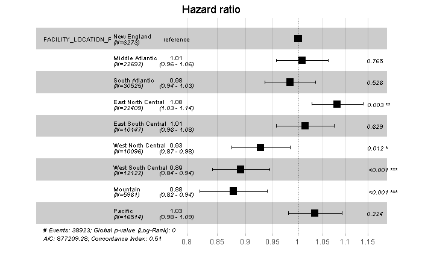

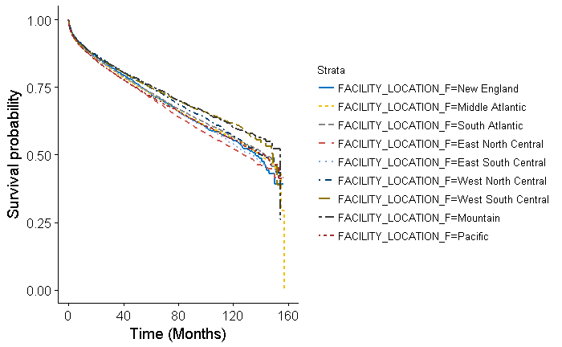

```r
uni_var(test_var = "FACILITY_LOCATION_F", data_imp = data)
```

## Facility Geography

```
_________________________________________________

## FACILITY_GEOGRAPHY
_________________________________________________
Call: survfit(formula = Surv(DX_LASTCONTACT_DEATH_MONTHS, PUF_VITAL_STATUS ==
    0) ~ FACILITY_GEOGRAPHY, data = data)

   9140 observations deleted due to missingness
                                 n events median 0.95LCL 0.95UCL
FACILITY_GEOGRAPHY=Northeast 28965   8218    139     135     142
FACILITY_GEOGRAPHY=South     42647  11770    147     142     148
FACILITY_GEOGRAPHY=Midwest   42652  12679    133     129     136
FACILITY_GEOGRAPHY=West      22475   6256    146     143      NA

Call: survfit(formula = Surv(DX_LASTCONTACT_DEATH_MONTHS, PUF_VITAL_STATUS ==
    0) ~ FACILITY_GEOGRAPHY, data = data)

9140 observations deleted due to missingness
                FACILITY_GEOGRAPHY=Northeast
 time n.risk n.event survival std.err lower 95% CI upper 95% CI
   12  24433    3142    0.889 0.00187        0.885        0.892
   24  21005    1214    0.843 0.00219        0.838        0.847
   36  17128     980    0.800 0.00247        0.795        0.805
   48  13843     747    0.762 0.00271        0.757        0.768
   60  10695     626    0.724 0.00298        0.719        0.730
  120   1576    1386    0.560 0.00499        0.551        0.570

                FACILITY_GEOGRAPHY=South
 time n.risk n.event survival std.err lower 95% CI upper 95% CI
   12  36016    4521    0.891 0.00153        0.888        0.894
   24  31081    1796    0.845 0.00180        0.842        0.849
   36  25780    1305    0.807 0.00200        0.803        0.811
   48  20913    1140    0.768 0.00221        0.764        0.773
   60  16549     837    0.735 0.00240        0.730        0.740
  120   2484    2011    0.579 0.00402        0.571        0.587

                FACILITY_GEOGRAPHY=Midwest
 time n.risk n.event survival std.err lower 95% CI upper 95% CI
   12  36103    4560    0.890 0.00153        0.887        0.893
   24  31118    1921    0.841 0.00181        0.838        0.845
```

[output cut: 29 more lines]

```
FACILITY_GEOGRAPHYMidwest  0.02112   1.02134  0.01416  1.491  0.13601
FACILITY_GEOGRAPHYWest    -0.01509   0.98503  0.01678 -0.899  0.36859
---
Signif. codes:  0 *** 0.001 ** 0.01 * 0.05 . 0.1   1

                          exp(coef) exp(-coef) lower .95 upper .95
FACILITY_GEOGRAPHYSouth      0.9519     1.0505    0.9255    0.9791
FACILITY_GEOGRAPHYMidwest    1.0213     0.9791    0.9934    1.0501
FACILITY_GEOGRAPHYWest       0.9850     1.0152    0.9532    1.0180

Concordance= 0.504  (se = 0.002 )
Rsquare= 0   (max possible= 0.998 )
Likelihood ratio test= 31.49  on 3 df,   p=6.696e-07
Wald test            = 31.4  on 3 df,   p=6.997e-07
Score (logrank) test = 31.41  on 3 df,   p=6.964e-07
```

```
Removed 1 rows containing missing values (geom_errorbar).
```

```
## Unadjusted Kaplan Meier Overall Survival Curve for:  FACILITY_GEOGRAPHY
```

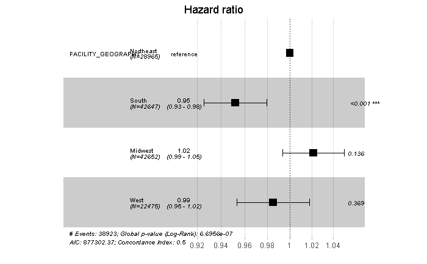

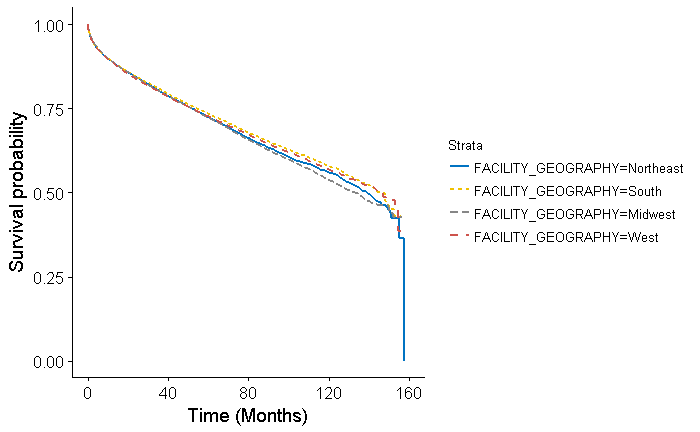

```r
uni_var(test_var = "FACILITY_GEOGRAPHY", data_imp = data)
```

## Age Group

```
_________________________________________________

## AGE_F
_________________________________________________
Call: survfit(formula = Surv(DX_LASTCONTACT_DEATH_MONTHS, PUF_VITAL_STATUS ==
    0) ~ AGE_F, data = data)

   25 observations deleted due to missingness
                   n events median 0.95LCL 0.95UCL
AGE_F=(0,54]   38937   2651     NA      NA      NA
AGE_F=(54,64]  30062   4264  157.3      NA      NA
AGE_F=(64,74]  31980   8067  140.8   138.1   145.9
AGE_F=(74,100] 44875  24329   55.3    54.3    56.2

Call: survfit(formula = Surv(DX_LASTCONTACT_DEATH_MONTHS, PUF_VITAL_STATUS ==
    0) ~ AGE_F, data = data)

25 observations deleted due to missingness
                AGE_F=(0,54]
 time n.risk n.event survival  std.err lower 95% CI upper 95% CI
   12  35710     886    0.977 0.000778        0.975        0.978
   24  31959     412    0.965 0.000960        0.963        0.967
   36  27394     299    0.955 0.001102        0.953        0.957
   48  23022     219    0.947 0.001228        0.944        0.949
   60  18725     219    0.937 0.001386        0.934        0.940
  120   3512     563    0.886 0.002667        0.881        0.891

                AGE_F=(54,64]
 time n.risk n.event survival std.err lower 95% CI upper 95% CI
   12  27021    1517    0.948 0.00130        0.946        0.951
   24  23790     666    0.924 0.00157        0.921        0.927
   36  20037     489    0.903 0.00179        0.900        0.907
   48  16637     378    0.885 0.00199        0.881        0.889
   60  13360     325    0.866 0.00221        0.862        0.870
  120   2304     812    0.767 0.00420        0.758        0.775

                AGE_F=(64,74]
 time n.risk n.event survival std.err lower 95% CI upper 95% CI
   12  27604    2868    0.908 0.00164        0.905        0.911
   24  23888    1226    0.866 0.00195        0.862        0.870
```

[output cut: 29 more lines]

```
AGE_F(64,74]   1.44072   4.22372  0.02239  64.33   <2e-16 ***
AGE_F(74,100]  2.47030  11.82599  0.02052 120.38   <2e-16 ***
---
Signif. codes:  0 *** 0.001 ** 0.01 * 0.05 . 0.1   1

              exp(coef) exp(-coef) lower .95 upper .95
AGE_F(54,64]      2.197    0.45524     2.093     2.306
AGE_F(64,74]      4.224    0.23676     4.042     4.413
AGE_F(74,100]    11.826    0.08456    11.360    12.311

Concordance= 0.725  (se = 0.002 )
Rsquare= 0.185   (max possible= 0.998 )
Likelihood ratio test= 29807  on 3 df,   p=0
Wald test            = 24089  on 3 df,   p=0
Score (logrank) test = 32448  on 3 df,   p=0
```

```
Removed 1 rows containing missing values (geom_errorbar).
```

```
## Unadjusted Kaplan Meier Overall Survival Curve for:  AGE_F
```

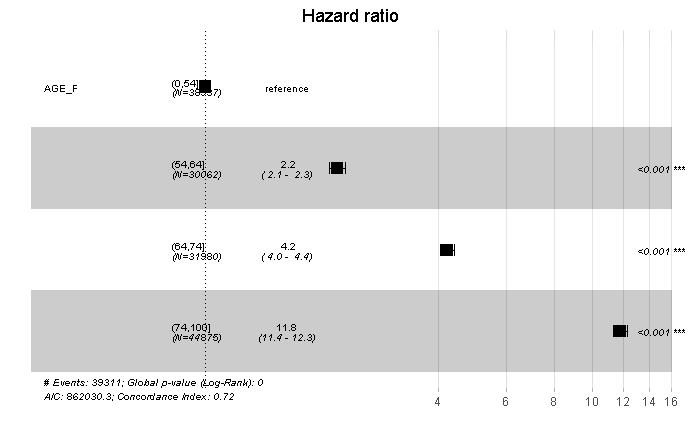

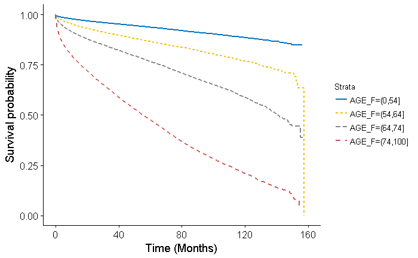

```r
uni_var(test_var = "AGE_F", data_imp = data)
```

## Age Group

```
_________________________________________________

## AGE_40
_________________________________________________
Call: survfit(formula = Surv(DX_LASTCONTACT_DEATH_MONTHS, PUF_VITAL_STATUS ==
    0) ~ AGE_40, data = data)

   25 observations deleted due to missingness
                     n events median 0.95LCL 0.95UCL
AGE_40=(0,40]    10234    453     NA      NA      NA
AGE_40=(40,100] 135620  38858    139     137     141

Call: survfit(formula = Surv(DX_LASTCONTACT_DEATH_MONTHS, PUF_VITAL_STATUS ==
    0) ~ AGE_40, data = data)

25 observations deleted due to missingness
                AGE_40=(0,40]
 time n.risk n.event survival std.err lower 95% CI upper 95% CI
   12   9388     149    0.985 0.00122        0.983        0.987
   24   8363      74    0.977 0.00153        0.974        0.980
   36   7166      41    0.972 0.00172        0.968        0.975
   48   6015      40    0.966 0.00195        0.962        0.970
   60   4842      44    0.958 0.00227        0.953        0.962
  120    916      98    0.923 0.00448        0.914        0.931

                AGE_40=(40,100]
 time n.risk n.event survival  std.err lower 95% CI upper 95% CI
   12 114231   14666    0.889 0.000864        0.887        0.891
   24  98248    5935    0.841 0.001018        0.839        0.843
   36  80904    4421    0.800 0.001138        0.798        0.803
   48  65495    3563    0.762 0.001251        0.760        0.765
   60  51374    2875    0.726 0.001366        0.723        0.728
  120   7950    6836    0.557 0.002296        0.553        0.562





## Univariable Cox Proportional Hazard Model for:  AGE_40

Call:
coxph(formula = Surv(DX_LASTCONTACT_DEATH_MONTHS, PUF_VITAL_STATUS ==
    0) ~ AGE_40, data = data)

  n= 145854, number of events= 39311
   (25 observations deleted due to missingness)

                  coef exp(coef) se(coef)     z Pr(>|z|)
AGE_40(40,100] 2.00903   7.45606  0.04726 42.51   <2e-16 ***
---
Signif. codes:  0 *** 0.001 ** 0.01 * 0.05 . 0.1   1

               exp(coef) exp(-coef) lower .95 upper .95
AGE_40(40,100]     7.456     0.1341     6.796      8.18

Concordance= 0.533  (se = 0.001 )
Rsquare= 0.026   (max possible= 0.998 )
Likelihood ratio test= 3820  on 1 df,   p=0
Wald test            = 1807  on 1 df,   p=0
Score (logrank) test = 2503  on 1 df,   p=0
```

```
Removed 1 rows containing missing values (geom_errorbar).
```

```
## Unadjusted Kaplan Meier Overall Survival Curve for:  AGE_40
```

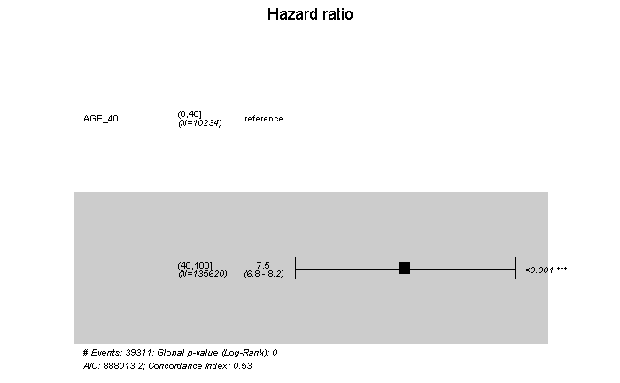

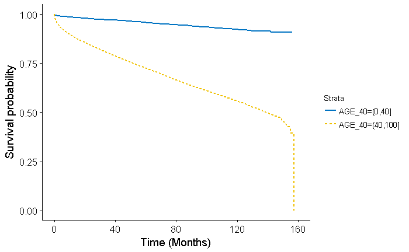

```r
uni_var(test_var = "AGE_40", data_imp = data)
```

## Sex

```
_________________________________________________

## SEX_F
_________________________________________________
Call: survfit(formula = Surv(DX_LASTCONTACT_DEATH_MONTHS, PUF_VITAL_STATUS ==
    0) ~ SEX_F, data = data)

                  n events median 0.95LCL 0.95UCL
SEX_F=Female 108205  27022    152     150      NA
SEX_F=Male    37674  12296    122     120     126

Call: survfit(formula = Surv(DX_LASTCONTACT_DEATH_MONTHS, PUF_VITAL_STATUS ==
    0) ~ SEX_F, data = data)

                SEX_F=Female
 time n.risk n.event survival  std.err lower 95% CI upper 95% CI
   12  93001    9761    0.907 0.000893        0.906        0.909
   24  80612    4143    0.865 0.001064        0.863        0.867
   36  66881    3098    0.830 0.001199        0.827        0.832
   48  54567    2530    0.796 0.001327        0.793        0.798
   60  43054    2066    0.763 0.001458        0.760        0.766
  120   6927    5012    0.607 0.002519        0.602        0.612

                SEX_F=Male
 time n.risk n.event survival std.err lower 95% CI upper 95% CI
   12  30636    5058    0.862 0.00180        0.859        0.866
   24  26014    1868    0.807 0.00209        0.803        0.811
   36  21202    1364    0.762 0.00231        0.757        0.766
   48  16953    1074    0.720 0.00251        0.715        0.725
   60  13170     853    0.680 0.00271        0.675        0.686
  120   1940    1922    0.507 0.00441        0.499        0.516





## Univariable Cox Proportional Hazard Model for:  SEX_F

Call:
coxph(formula = Surv(DX_LASTCONTACT_DEATH_MONTHS, PUF_VITAL_STATUS ==
    0) ~ SEX_F, data = data)

  n= 145879, number of events= 39318

             coef exp(coef) se(coef)     z Pr(>|z|)
SEX_FMale 0.34693   1.41472  0.01088 31.88   <2e-16 ***
---
Signif. codes:  0 *** 0.001 ** 0.01 * 0.05 . 0.1   1

          exp(coef) exp(-coef) lower .95 upper .95
SEX_FMale     1.415     0.7069     1.385     1.445

Concordance= 0.537  (se = 0.001 )
Rsquare= 0.007   (max possible= 0.998 )
Likelihood ratio test= 969.9  on 1 df,   p=0
Wald test            = 1016  on 1 df,   p=0
Score (logrank) test = 1027  on 1 df,   p=0
```

```
Removed 1 rows containing missing values (geom_errorbar).
```

```
## Unadjusted Kaplan Meier Overall Survival Curve for:  SEX_F
```

[figure not shown]

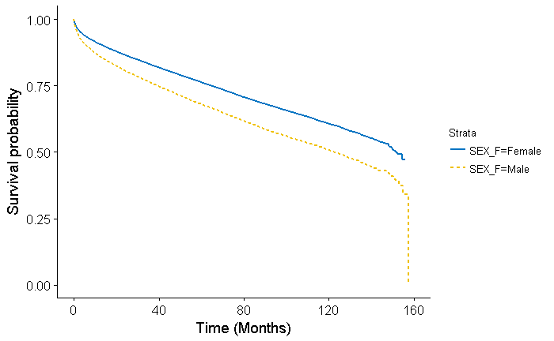

```r
data$SEX_F <- fct_relevel(data$SEX_F, "Female", after = 0)
uni_var(test_var = "SEX_F", data_imp = data)
```

## RACE_F

```
_________________________________________________

## RACE_F
_________________________________________________
Call: survfit(formula = Surv(DX_LASTCONTACT_DEATH_MONTHS, PUF_VITAL_STATUS ==
    0) ~ RACE_F, data = data)

                      n events median 0.95LCL 0.95UCL
RACE_F=White     119197  33012    146     143     148
RACE_F=Black      18121   4769     NA     143      NA
RACE_F=Other/Unk   4023    664     NA      NA      NA
RACE_F=Asian       4538    873     NA     150      NA

Call: survfit(formula = Surv(DX_LASTCONTACT_DEATH_MONTHS, PUF_VITAL_STATUS ==
    0) ~ RACE_F, data = data)

                RACE_F=White
 time n.risk n.event survival  std.err lower 95% CI upper 95% CI
   12 101132   12327    0.894 0.000903        0.892        0.896
   24  87308    5031    0.848 0.001066        0.846        0.850
   36  72142    3760    0.809 0.001194        0.806        0.811
   48  58615    3014    0.772 0.001313        0.769        0.775
   60  46143    2465    0.737 0.001435        0.734        0.739
  120   7382    5928    0.572 0.002413        0.568        0.577

                RACE_F=Black
 time n.risk n.event survival std.err lower 95% CI upper 95% CI
   12  15269    1850    0.895 0.00231        0.890        0.899
   24  13077     762    0.848 0.00274        0.843        0.854
   36  10792     541    0.811 0.00306        0.805        0.817
   48   8766     451    0.774 0.00338        0.767        0.781
   60   6807     354    0.739 0.00369        0.732        0.747
  120    962     762    0.591 0.00635        0.578        0.603

                RACE_F=Other/Unk
 time n.risk n.event survival std.err lower 95% CI upper 95% CI
   12   3423     280    0.928 0.00417        0.919        0.936
   24   2983      83    0.904 0.00481        0.894        0.913
   36   2504      68    0.882 0.00540        0.871        0.892
   48   2067      52    0.862 0.00594        0.850        0.873
```

[output cut: 26 more lines]

```
RACE_FOther/Unk -0.53977   0.58288  0.03920 -13.771   <2e-16 ***
RACE_FAsian     -0.32709   0.72102  0.03429  -9.539   <2e-16 ***
---
Signif. codes:  0 *** 0.001 ** 0.01 * 0.05 . 0.1   1

                exp(coef) exp(-coef) lower .95 upper .95
RACE_FBlack        0.9721      1.029    0.9430    1.0020
RACE_FOther/Unk    0.5829      1.716    0.5398    0.6294
RACE_FAsian        0.7210      1.387    0.6742    0.7711

Concordance= 0.51  (se = 0.001 )
Rsquare= 0.002   (max possible= 0.998 )
Likelihood ratio test= 319.3  on 3 df,   p=0
Wald test            = 275.2  on 3 df,   p=0
Score (logrank) test = 280.5  on 3 df,   p=0
```

```
Removed 1 rows containing missing values (geom_errorbar).
```

```
## Unadjusted Kaplan Meier Overall Survival Curve for:  RACE_F
```

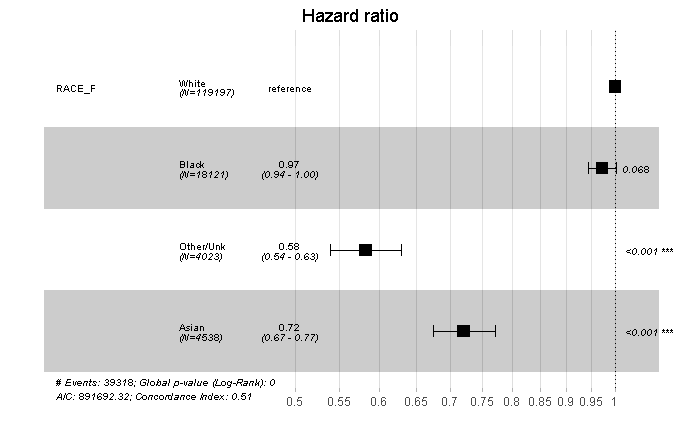

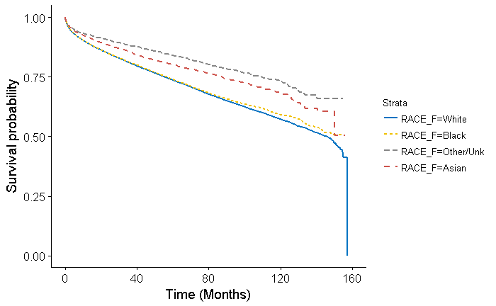

```r
uni_var(test_var = "RACE_F", data_imp = data)
```

## Hispanic

```
_________________________________________________

## HISPANIC
_________________________________________________
Call: survfit(formula = Surv(DX_LASTCONTACT_DEATH_MONTHS, PUF_VITAL_STATUS ==
    0) ~ HISPANIC, data = data)

                      n events median 0.95LCL 0.95UCL
HISPANIC=No      128789  35294    146     143     148
HISPANIC=Yes       8690   1519     NA      NA      NA
HISPANIC=Unknown   8400   2505    152     143      NA

Call: survfit(formula = Surv(DX_LASTCONTACT_DEATH_MONTHS, PUF_VITAL_STATUS ==
    0) ~ HISPANIC, data = data)

                HISPANIC=No
 time n.risk n.event survival  std.err lower 95% CI upper 95% CI
   12 109252   13289    0.894 0.000868        0.893        0.896
   24  94072    5428    0.848 0.001025        0.846        0.850
   36  77423    4020    0.809 0.001149        0.807        0.811
   48  62544    3247    0.772 0.001265        0.770        0.775
   60  48918    2628    0.737 0.001386        0.734        0.739
  120   7647    6185    0.573 0.002359        0.568        0.578

                HISPANIC=Yes
 time n.risk n.event survival std.err lower 95% CI upper 95% CI
   12   7291     642    0.922 0.00294        0.917        0.928
   24   6208     243    0.890 0.00350        0.883        0.897
   36   5034     178    0.862 0.00397        0.854        0.870
   48   4042     131    0.837 0.00440        0.829        0.846
   60   3149      94    0.816 0.00481        0.807        0.826
  120    422     216    0.715 0.00865        0.698        0.732

                HISPANIC=Unknown
 time n.risk n.event survival std.err lower 95% CI upper 95% CI
   12   7094     888    0.891 0.00344        0.885        0.898
   24   6346     340    0.848 0.00401        0.840        0.856
   36   5626     264    0.811 0.00442        0.803        0.820
   48   4934     226    0.777 0.00478        0.768        0.787
   60   4157     197    0.744 0.00512        0.734        0.754
```

[output cut: 14 more lines]

```
                    coef exp(coef) se(coef)       z Pr(>|z|)
HISPANICYes     -0.41649   0.65936  0.02620 -15.894   <2e-16 ***
HISPANICUnknown -0.03483   0.96577  0.02069  -1.683   0.0923 .
---
Signif. codes:  0 *** 0.001 ** 0.01 * 0.05 . 0.1   1

                exp(coef) exp(-coef) lower .95 upper .95
HISPANICYes        0.6594      1.517    0.6263    0.6941
HISPANICUnknown    0.9658      1.035    0.9274    1.0057

Concordance= 0.509  (se = 0.001 )
Rsquare= 0.002   (max possible= 0.998 )
Likelihood ratio test= 288.1  on 2 df,   p=0
Wald test            = 253.3  on 2 df,   p=0
Score (logrank) test = 256.9  on 2 df,   p=0
```

```
Removed 1 rows containing missing values (geom_errorbar).
```

```
## Unadjusted Kaplan Meier Overall Survival Curve for:  HISPANIC
```

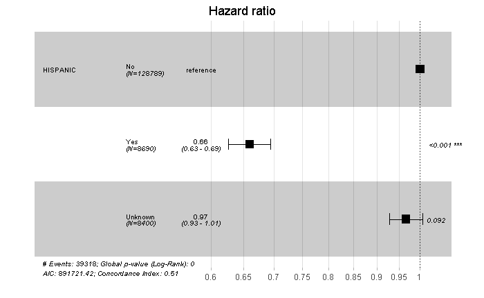

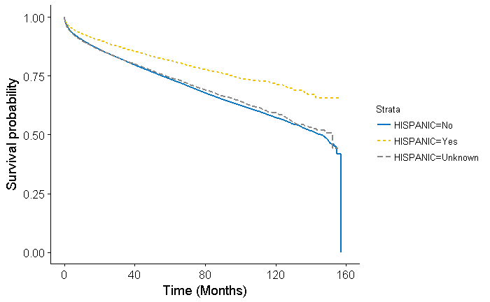

```r
uni_var(test_var = "HISPANIC", data_imp = data)
```

## Insurance Status

```
_________________________________________________

## INSURANCE_F
_________________________________________________
Call: survfit(formula = Surv(DX_LASTCONTACT_DEATH_MONTHS, PUF_VITAL_STATUS ==
    0) ~ INSURANCE_F, data = data)

                                 n events median 0.95LCL 0.95UCL
INSURANCE_F=Private          55445   6441  157.3      NA      NA
INSURANCE_F=None              5403    738     NA      NA      NA
INSURANCE_F=Medicaid          8595   1538  152.2   152.2      NA
INSURANCE_F=Medicare         71973  29572   85.5    84.3    86.7
INSURANCE_F=Other Government  1572    299  153.1   153.1      NA
INSURANCE_F=Unknown           2891    730  149.3   149.3      NA

Call: survfit(formula = Surv(DX_LASTCONTACT_DEATH_MONTHS, PUF_VITAL_STATUS ==
    0) ~ INSURANCE_F, data = data)

                INSURANCE_F=Private
 time n.risk n.event survival  std.err lower 95% CI upper 95% CI
   12  50329    2290    0.958 0.000866        0.956        0.959
   24  44864     995    0.938 0.001049        0.936        0.940
   36  38295     706    0.922 0.001189        0.920        0.924
   48  32021     566    0.907 0.001323        0.905        0.910
   60  25996     501    0.892 0.001472        0.889        0.895
  120   4757    1244    0.814 0.002717        0.809        0.819

                INSURANCE_F=None
 time n.risk n.event survival std.err lower 95% CI upper 95% CI
   12   4561     290    0.943 0.00325        0.937        0.949
   24   3915     112    0.919 0.00391        0.911        0.926
   36   3231      96    0.894 0.00453        0.885        0.903
   48   2597      66    0.874 0.00506        0.864        0.884
   60   1974      54    0.854 0.00566        0.843        0.865
  120    287     113    0.756 0.01087        0.735        0.778

                INSURANCE_F=Medicaid
 time n.risk n.event survival std.err lower 95% CI upper 95% CI
   12   7286     631    0.924 0.00292        0.918        0.929
   24   6177     240    0.892 0.00348        0.885        0.898
```

[output cut: 50 more lines]

```
---
Signif. codes:  0 *** 0.001 ** 0.01 * 0.05 . 0.1   1

                            exp(coef) exp(-coef) lower .95 upper .95
INSURANCE_FNone                 1.376     0.7266     1.275     1.485
INSURANCE_FMedicaid             1.813     0.5516     1.715     1.917
INSURANCE_FMedicare             4.457     0.2244     4.338     4.579
INSURANCE_FOther Government     1.895     0.5278     1.687     2.128
INSURANCE_FUnknown              2.189     0.4568     2.028     2.363

Concordance= 0.655  (se = 0.001 )
Rsquare= 0.104   (max possible= 0.998 )
Likelihood ratio test= 16080  on 5 df,   p=0
Wald test            = 13102  on 5 df,   p=0
Score (logrank) test = 15403  on 5 df,   p=0
```

```
Removed 1 rows containing missing values (geom_errorbar).
```

```
## Unadjusted Kaplan Meier Overall Survival Curve for:  INSURANCE_F
```

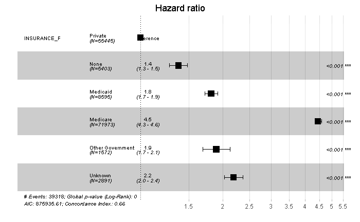

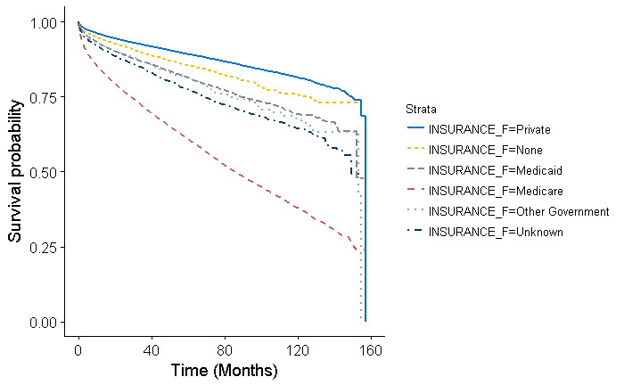

```r
uni_var(test_var = "INSURANCE_F", data_imp = data)
```

## Income

```
_________________________________________________

## INCOME_F
_________________________________________________
Call: survfit(formula = Surv(DX_LASTCONTACT_DEATH_MONTHS, PUF_VITAL_STATUS ==
    0) ~ INCOME_F, data = data)

   1337 observations deleted due to missingness
                               n events median 0.95LCL 0.95UCL
INCOME_F=Less than $38,000 25192   7386    136     133     143
INCOME_F=$38,000 - $47,999 33127   9377    139     135     144
INCOME_F=$48,000 - $62,999 39225  10415    148     142      NA
INCOME_F=$63,000 +         46998  11402    155     150      NA

Call: survfit(formula = Surv(DX_LASTCONTACT_DEATH_MONTHS, PUF_VITAL_STATUS ==
    0) ~ INCOME_F, data = data)

1337 observations deleted due to missingness
                INCOME_F=Less than $38,000
 time n.risk n.event survival std.err lower 95% CI upper 95% CI
   12  21035    2858    0.883 0.00205        0.879        0.887
   24  17989    1120    0.834 0.00241        0.830        0.839
   36  14866     824    0.793 0.00268        0.788        0.799
   48  12061     714    0.752 0.00295        0.746        0.758
   60   9466     491    0.719 0.00319        0.712        0.725
  120   1441    1285    0.548 0.00535        0.538        0.559

                INCOME_F=$38,000 - $47,999
 time n.risk n.event survival std.err lower 95% CI upper 95% CI
   12  27870    3503    0.891 0.00173        0.888        0.895
   24  23966    1440    0.843 0.00205        0.839        0.847
   36  19781    1068    0.803 0.00230        0.799        0.808
   48  16083     827    0.767 0.00252        0.762        0.772
   60  12705     715    0.730 0.00275        0.724        0.735
  120   2027    1676    0.560 0.00464        0.551        0.570

                INCOME_F=$48,000 - $62,999
 time n.risk n.event survival std.err lower 95% CI upper 95% CI
   12  33432    3814    0.900 0.00153        0.897        0.903
   24  28841    1638    0.854 0.00183        0.851        0.858
```

[output cut: 29 more lines]

```
INCOME_F$48,000 - $62,999 -0.12423   0.88317  0.01521  -8.167 3.33e-16 ***
INCOME_F$63,000 +         -0.23024   0.79435  0.01494 -15.414  < 2e-16 ***
---
Signif. codes:  0 *** 0.001 ** 0.01 * 0.05 . 0.1   1

                          exp(coef) exp(-coef) lower .95 upper .95
INCOME_F$38,000 - $47,999    0.9498      1.053    0.9212    0.9792
INCOME_F$48,000 - $62,999    0.8832      1.132    0.8572    0.9099
INCOME_F$63,000 +            0.7943      1.259    0.7714    0.8179

Concordance= 0.524  (se = 0.002 )
Rsquare= 0.002   (max possible= 0.998 )
Likelihood ratio test= 289  on 3 df,   p=0
Wald test            = 287.7  on 3 df,   p=0
Score (logrank) test = 288.5  on 3 df,   p=0
```

```
Removed 1 rows containing missing values (geom_errorbar).
```

```
## Unadjusted Kaplan Meier Overall Survival Curve for:  INCOME_F
```

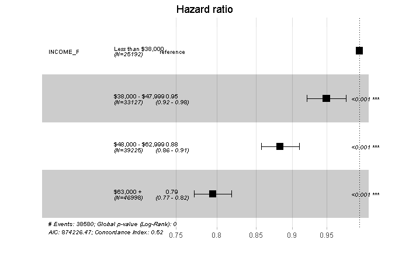

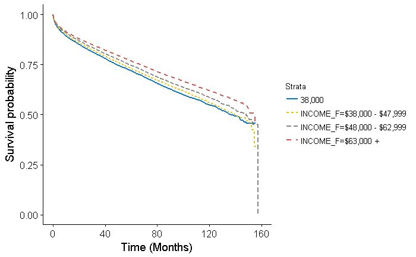

```r
uni_var(test_var = "INCOME_F", data_imp = data)
```

## Education

```
_________________________________________________

## EDUCATION_F
_________________________________________________
Call: survfit(formula = Surv(DX_LASTCONTACT_DEATH_MONTHS, PUF_VITAL_STATUS ==
    0) ~ EDUCATION_F, data = data)

   1266 observations deleted due to missingness
                             n events median 0.95LCL 0.95UCL
EDUCATION_F=21% or more  25079   6786    147     139      NA
EDUCATION_F=13 - 20.9%   36940  10255    143     140     149
EDUCATION_F=7 - 12.9%    46620  12660    147     143     151
EDUCATION_F=Less than 7% 35974   8899    151     149      NA

Call: survfit(formula = Surv(DX_LASTCONTACT_DEATH_MONTHS, PUF_VITAL_STATUS ==
    0) ~ EDUCATION_F, data = data)

1266 observations deleted due to missingness
                EDUCATION_F=21% or more
 time n.risk n.event survival std.err lower 95% CI upper 95% CI
   12  20975    2649    0.891 0.00200        0.887        0.895
   24  17996    1043    0.845 0.00235        0.840        0.850
   36  14853     764    0.806 0.00263        0.801        0.812
   48  12035     651    0.768 0.00290        0.763        0.774
   60   9437     453    0.736 0.00314        0.730        0.743
  120   1371    1138    0.576 0.00547        0.565        0.587

                EDUCATION_F=13 - 20.9%
 time n.risk n.event survival std.err lower 95% CI upper 95% CI
   12  31010    3924    0.891 0.00165        0.887        0.894
   24  26569    1604    0.843 0.00195        0.839        0.846
   36  21864    1154    0.803 0.00217        0.799        0.808
   48  17742     909    0.767 0.00239        0.762        0.772
   60  13907     743    0.732 0.00260        0.727        0.737
  120   2158    1775    0.571 0.00435        0.563        0.580

                EDUCATION_F=7 - 12.9%
 time n.risk n.event survival std.err lower 95% CI upper 95% CI
   12  39672    4731    0.896 0.00143        0.893        0.899
   24  34271    1900    0.851 0.00169        0.848        0.855
```

[output cut: 29 more lines]

```
EDUCATION_F7 - 12.9%    -0.02653   0.97382  0.01505 -1.763   0.0778 .
EDUCATION_FLess than 7% -0.14606   0.86410  0.01612 -9.062   <2e-16 ***
---
Signif. codes:  0 *** 0.001 ** 0.01 * 0.05 . 0.1   1

                        exp(coef) exp(-coef) lower .95 upper .95
EDUCATION_F13 - 20.9%      1.0187     0.9817    0.9879    1.0504
EDUCATION_F7 - 12.9%       0.9738     1.0269    0.9455    1.0030
EDUCATION_FLess than 7%    0.8641     1.1573    0.8372    0.8918

Concordance= 0.518  (se = 0.002 )
Rsquare= 0.001   (max possible= 0.998 )
Likelihood ratio test= 151.1  on 3 df,   p=0
Wald test            = 148.1  on 3 df,   p=0
Score (logrank) test = 148.3  on 3 df,   p=0
```

```
Removed 1 rows containing missing values (geom_errorbar).
```

```
## Unadjusted Kaplan Meier Overall Survival Curve for:  EDUCATION_F
```

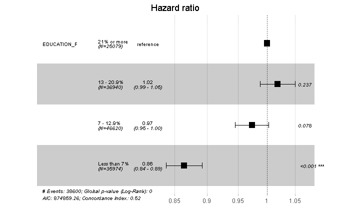

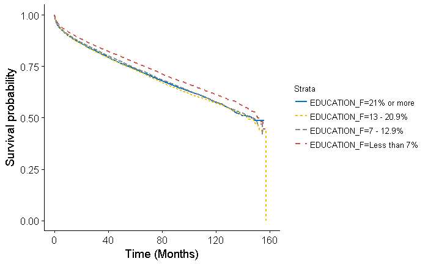

```r
uni_var(test_var = "EDUCATION_F", data_imp = data)
```

## Urban/Rural

```
_________________________________________________

## U_R_F
_________________________________________________
Call: survfit(formula = Surv(DX_LASTCONTACT_DEATH_MONTHS, PUF_VITAL_STATUS ==
    0) ~ U_R_F, data = data)

   4402 observations deleted due to missingness
                 n events median 0.95LCL 0.95UCL
U_R_F=Metro 121511  32522    148     147     150
U_R_F=Urban  17686   4664    144     140      NA
U_R_F=Rural   2280    661    129     124      NA

Call: survfit(formula = Surv(DX_LASTCONTACT_DEATH_MONTHS, PUF_VITAL_STATUS ==
    0) ~ U_R_F, data = data)

4402 observations deleted due to missingness
                U_R_F=Metro
 time n.risk n.event survival  std.err lower 95% CI upper 95% CI
   12 103361   12195    0.897 0.000883        0.895        0.899
   24  89240    5000    0.852 0.001044        0.850        0.854
   36  73681    3745    0.814 0.001171        0.811        0.816
   48  59807    3011    0.778 0.001291        0.775        0.780
   60  46962    2419    0.743 0.001412        0.740        0.746
  120   7301    5693    0.585 0.002402        0.580        0.589

                U_R_F=Urban
 time n.risk n.event survival std.err lower 95% CI upper 95% CI
   12  14906    1748    0.898 0.00231        0.894        0.903
   24  12844     681    0.855 0.00272        0.850        0.861
   36  10666     496    0.820 0.00304        0.814        0.826
   48   8672     408    0.786 0.00335        0.779        0.792
   60   6872     333    0.753 0.00367        0.746        0.760
  120   1189     917    0.582 0.00628        0.570        0.595

                U_R_F=Rural
 time n.risk n.event survival std.err lower 95% CI upper 95% CI
   12   1909     242    0.890 0.00665        0.877        0.904
   24   1649      99    0.842 0.00786        0.827        0.858
   36   1373      67    0.806 0.00870        0.789        0.823
```

[output cut: 17 more lines]

```
               coef exp(coef) se(coef)      z Pr(>|z|)
U_R_FUrban -0.01762   0.98253  0.01566 -1.125    0.260
U_R_FRural  0.07306   1.07579  0.03929  1.859    0.063 .
---
Signif. codes:  0 *** 0.001 ** 0.01 * 0.05 . 0.1   1

           exp(coef) exp(-coef) lower .95 upper .95
U_R_FUrban    0.9825     1.0178    0.9528     1.013
U_R_FRural    1.0758     0.9295    0.9961     1.162

Concordance= 0.502  (se = 0.001 )
Rsquare= 0   (max possible= 0.998 )
Likelihood ratio test= 4.87  on 2 df,   p=0.08781
Wald test            = 4.95  on 2 df,   p=0.08435
Score (logrank) test = 4.95  on 2 df,   p=0.08428
```

```
Removed 1 rows containing missing values (geom_errorbar).
```

```
## Unadjusted Kaplan Meier Overall Survival Curve for:  U_R_F
```

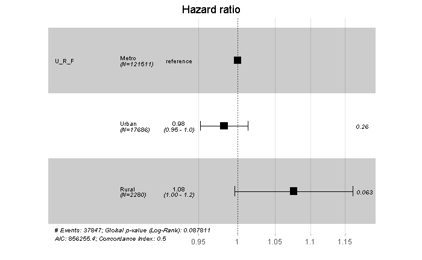

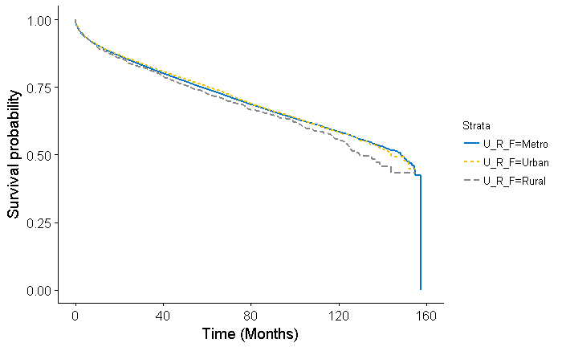

```r
uni_var(test_var = "U_R_F", data_imp = data)
```

## Comorbidities

```
_________________________________________________

## CDCC_TOTAL
_________________________________________________
Call: survfit(formula = Surv(DX_LASTCONTACT_DEATH_MONTHS, PUF_VITAL_STATUS ==
    0) ~ CDCC_TOTAL, data = data)

                  n events median 0.95LCL 0.95UCL
CDCC_TOTAL=0 106572  23818  154.4   153.1      NA
CDCC_TOTAL=1  25745   9075  105.3   101.9   109.0
CDCC_TOTAL=2   8900   3981   72.4    69.1    75.4
CDCC_TOTAL=3   4662   2444   51.8    48.4    55.1

Call: survfit(formula = Surv(DX_LASTCONTACT_DEATH_MONTHS, PUF_VITAL_STATUS ==
    0) ~ CDCC_TOTAL, data = data)

                CDCC_TOTAL=0
 time n.risk n.event survival  std.err lower 95% CI upper 95% CI
   12  92847    8175    0.921 0.000837        0.920        0.923
   24  80995    3648    0.884 0.001009        0.882        0.886
   36  67701    2758    0.851 0.001145        0.849        0.853
   48  55628    2249    0.821 0.001272        0.818        0.823
   60  44232    1866    0.791 0.001405        0.788        0.793
  120   7380    4688    0.642 0.002490        0.638        0.647

                CDCC_TOTAL=1
 time n.risk n.event survival std.err lower 95% CI upper 95% CI
   12  20795    3681    0.853 0.00224        0.849        0.858
   24  17529    1399    0.794 0.00259        0.788        0.799
   36  14051    1010    0.744 0.00286        0.738        0.750
   48  11141     789    0.699 0.00311        0.693        0.705
   60   8502     633    0.655 0.00337        0.648        0.662
  120   1123    1465    0.461 0.00545        0.451        0.472

                CDCC_TOTAL=2
 time n.risk n.event survival std.err lower 95% CI upper 95% CI
   12   6748    1762    0.797 0.00431        0.789        0.806
   24   5545     578    0.726 0.00484        0.717        0.736
   36   4358     446    0.664 0.00526        0.653        0.674
   48   3310     374    0.601 0.00567        0.590        0.613
```

[output cut: 26 more lines]

```
CDCC_TOTAL2 0.92450   2.52060  0.01715 53.92   <2e-16 ***
CDCC_TOTAL3 1.22275   3.39650  0.02129 57.42   <2e-16 ***
---
Signif. codes:  0 *** 0.001 ** 0.01 * 0.05 . 0.1   1

            exp(coef) exp(-coef) lower .95 upper .95
CDCC_TOTAL1     1.808     0.5530     1.765     1.853
CDCC_TOTAL2     2.521     0.3967     2.437     2.607
CDCC_TOTAL3     3.397     0.2944     3.258     3.541

Concordance= 0.59  (se = 0.001 )
Rsquare= 0.038   (max possible= 0.998 )
Likelihood ratio test= 5710  on 3 df,   p=0
Wald test            = 6503  on 3 df,   p=0
Score (logrank) test = 6999  on 3 df,   p=0
```

```
Removed 1 rows containing missing values (geom_errorbar).
```

```
## Unadjusted Kaplan Meier Overall Survival Curve for:  CDCC_TOTAL
```

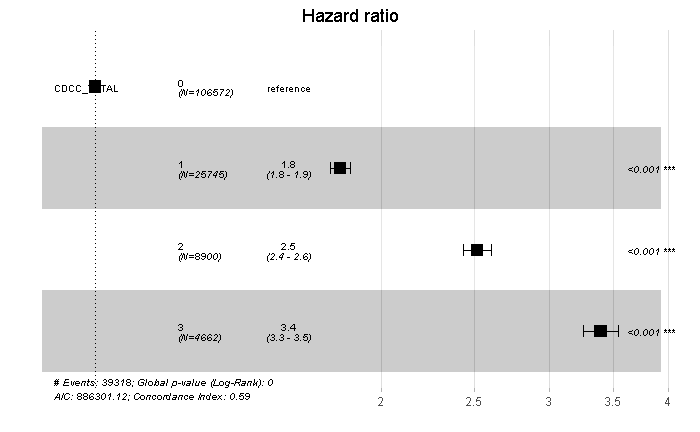

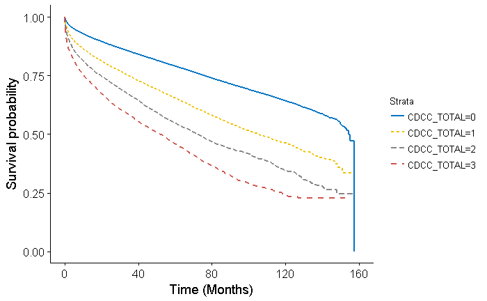

```r
uni_var(test_var = "CDCC_TOTAL", data_imp = data)
```

## Class (treatment at performing facility)

```
_________________________________________________

## CLASS_OF_CASE_F
_________________________________________________
Call: survfit(formula = Surv(DX_LASTCONTACT_DEATH_MONTHS, PUF_VITAL_STATUS ==
    0) ~ CLASS_OF_CASE_F, data = data)

      n  events  median 0.95LCL 0.95UCL
 145879   39318     148     146     150

Call: survfit(formula = Surv(DX_LASTCONTACT_DEATH_MONTHS, PUF_VITAL_STATUS ==
    0) ~ CLASS_OF_CASE_F, data = data)

 time n.risk n.event survival  std.err lower 95% CI upper 95% CI
   12 123637   14819    0.896 0.000811        0.894        0.897
   24 106626    6011    0.850 0.000958        0.849        0.852
   36  88083    4462    0.812 0.001073        0.810        0.814
   48  71520    3604    0.776 0.001181        0.774        0.779
   60  56224    2919    0.741 0.001292        0.739        0.744
  120   8867    6934    0.581 0.002191        0.577        0.586




## Univariable Cox Proportional Hazard Model for:  CLASS_OF_CASE_F

Call:
coxph(formula = Surv(DX_LASTCONTACT_DEATH_MONTHS, PUF_VITAL_STATUS ==
    0) ~ CLASS_OF_CASE_F, data = data)

  n= 145879, number of events= 39318

                             coef exp(coef) se(coef)  z Pr(>|z|)
CLASS_OF_CASE_FAll_Part_Prim    0         1        0 NA       NA

                             exp(coef) exp(-coef) lower .95 upper .95
CLASS_OF_CASE_FAll_Part_Prim         1          1         1         1

Concordance= 0.5  (se = 0 )
Rsquare= 0   (max possible= 0.998 )
Likelihood ratio test= 0  on 1 df,   p=1
Wald test            = NaN  on 1 df,   p=NaN
Score (logrank) test = 0  on 1 df,   p=1
```

```
relative range of values =   0 * EPS, is small (axis 0)Removed 1 rows containing missing values (geom_errorbar).
```

```
## Unadjusted Kaplan Meier Overall Survival Curve for:  CLASS_OF_CASE_F
```

[figure not shown]

```r
uni_var(test_var = "CLASS_OF_CASE_F", data_imp = data)
```

[output not shown]